# Resolución Actividad 3 máster Bioinformática UNIR (2025)

Lote 2-5: Luis Saul Vela del Castillo, Carme Delicado Mercader, Raul Larriba Salinas

2025-05-29

# Índice

1. Preparación del entorno
2. Aplicar un PCA
3. Gráficos descriptivos de los PC
4. Tabla descriptiva
5. Modelo predictivo de regresión logística

## 1. Preparación del entorno

Nos ubicamos en el directorio donde tenemos los datos y cargamos las librerías.

```r
library(stats)
library(ggplot2)
library(dplyr)
library(tidyr)
library(gtsummary)
library(flextable)
library(officer)
library(gt)
library(gtExtras)

#setwd("C:/Users/luisv/OneDrive/Desktop/UNIR/Estad'istica y R para ciencias de la salud")
setwd("C:/Users/larri/Desktop/MASTER BIOINFORMATICA/ESTADÍSTICA Y R/ACTIVIDADES/ACTIVIDAD 3- R y Stat/mubio02_act3")
#setwd("C:/Users/carme/OneDrive/Escritorio/BIOINFORMÁTICA/1R SEMESTRE/ESTADÍSTICA Y R PARA CIENCIAS DE LA SALUD/ACTIVIDAD_3")
```

Podemos observar que tenemos 65 observaciones (los 65 pacientes) y 104 variables, estas pertenecen a los 46 genes y a variables bioquímicas, síntomas y otras variables sociodemográficas.

Leemos los datos y filtramos las columnas de genes.

```r
getwd()
```

```
## [1] "C:/Users/larri/Desktop/MASTER BIOINFORMATICA/ESTADÍSTICA Y R/ACTIVIDADES/ACTIVIDAD 3- R y Stat/mubio02_act3"
```

```r
list.files()
```

```
## [1] "~$TIVIDAD 3 - GRUPAL.docx"
## [2] "ACTIVIDAD 3 - GRUPAL.docx"
## [3] "Dataset expresión genes.csv"
## [4] "Dataset expresión genes.RData"
## [5] "Resolución-Actividad-3-máster-Bioinformática-UNIR--2025--1--2-.html"
## [6] "Resolución-Actividad-3-máster-Bioinformática-UNIR--2025--1--2-.Rmd"
## [7] "Resolución Actividad 3 máster Bioinformática UNIR (2025) 1 (2).Rmd"
```

```r
data <- read.csv("Dataset expresión genes.csv", stringsAsFactors = TRUE)
str(data)
```

```
## 'data.frame':    65 obs. of  104 variables:
##  $ X             : int  1 2 3 4 5 6 7 8 9 10 ...
##  $ id            : int  1 2 3 4 5 6 7 8 9 10 ...
##  $ edad          : num  55.7 48.7 63.6 55.3 74.1 ...
##  $ sexo          : Factor w/ 2 levels "mujer","varon": 1 2 1 1 2 1 1 1 2 1 ...
##  $ exfumador     : Factor w/ 2 levels "no","si": 2 1 1 2 2 1 1 1 2 1 ...
##  $ hta           : Factor w/ 2 levels "no","si": 2 2 1 1 1 2 1 1 1 1 ...
##  $ dm            : Factor w/ 2 levels "no","si": 1 1 1 1 2 1 1 1 1 1 ...
##  $ alergia       : Factor w/ 2 levels "no","si": 2 1 1 1 1 1 1 1 1 1 ...
##  $ cardiopatia   : Factor w/ 2 levels "no","si": 2 1 1 1 2 1 1 1 1 1 ...
##  $ ETE           : Factor w/ 2 levels "no","si": 2 1 1 1 1 1 1 1 1 1 ...
##  $ neumopatia    : Factor w/ 2 levels "no","si": 2 2 2 1 2 1 1 1 1 1 ...
##  $ hepatopatia   : Factor w/ 2 levels "no","si": 1 1 1 1 1 1 1 1 1 1 ...
##  $ colelitiasis  : Factor w/ 2 levels "no","si": 1 1 1 1 1 2 1 1 1 1 ...
##  $ utolitiasis   : Factor w/ 2 levels "no","si": 1 1 1 1 1 1 1 1 1 1 ...
```

[output cut: 86 more lines]

```r
datos.genes <- select(data, starts_with("AQ_"))
```

Antes de empezar con los análisis vamos a ver si tenemos valores NA y 0 en nuestra base de datos.

```r
anyNA(data)
```

```
## [1] FALSE
```

```r
any(data == 0)
```

```
## [1] TRUE
```

No hay valores NA en nuestros datos, lo que nos permite continuar trabajando sabiendo que todas las celdas tienen valores disponibles.

Lo importante de buscar los valores=0 es ver que proporción representan en la muestra, es decir, si tenemos una variable que para cada paciente es 0, esa variable no nos está dando información y podríamos plantearnos obviarla. Pero hay que tener en cuenta que, si por ejemplo, tenemos en los datos variables de expresión génica o síntesis de proteína, pueden haber valores 0 que nos esten aportando información.

Miramos si tenemos alguna expresión génica con todos los valores=0, osea que el valor de la suma de alguna columna sea 65.

También miramos si algún paciente tiene todos los datos=0, es decir que la suma de alguna fila sea 46.

```r
zero_counts <- colSums(datos.genes == 0)
zero_counts
```

```
## AQ_ADIPOQ  AQ_ALOX5   AQ_ARG1   AQ_BMP2   AQ_CCL2   AQ_CCL5   AQ_CCR5  AQ_CD274
##        28         3         7         3         5         3         1         2
##   AQ_CD36   AQ_CHKA  AQ_CPT1A   AQ_CSF2  AQ_CXCR1   AQ_FASN  AQ_FOXO3  AQ_FOXP3
##         4        10         4        13         5         3         3         4
##   AQ_G6PD   AQ_GPD2   AQ_GPX1   AQ_IFNG   AQ_IL10   AQ_IL1B    AQ_IL6   AQ_IRS1
##         2        12         1         8         8         5        10         2
##   AQ_JAK1   AQ_JAK3   AQ_LDHA    AQ_LIF  AQ_MAPK1 AQ_NFE2L2  AQ_NFKB1  AQ_NLRP3
##         1         6         2        12         4         4         6         4
##   AQ_NOS2   AQ_NOX5  AQ_PDCD1  AQ_PPARG  AQ_PTAFR  AQ_PTGS2 AQ_SLC2A4   AQ_SOD1
##        19        20         1        11         2         3         3         6
## AQ_SREBF1  AQ_STAT3  AQ_TGFB1   AQ_TLR3   AQ_TLR4    AQ_TNF
##         1         2         2         8         9         4
```

```r
zero_counts_2 <- rowSums(datos.genes ==0)
zero_counts_2
```

```
##  [1]  2  0  5  2  2  6  0  1  2  0  0  3 44  6  7  2  5  4  4  0  0  3  0  4  2
## [26]  3  8  4  4  6  3  5  3  3  4  2  7  5  4  1  2  8  8  2  8  6  3  3  5  8
## [51]  5  8  5  2  7  3  2  2  0  5  3  1  6  2  6
```

Para las columnas todos los valores son <65 así que nos quedamos con todos los genes.

Para las filas todos los valores son <46, exceptuando el paciente 13, que tiene 44 0s. Podríamos plantearnos quitarlo del estudio.

Hacemos una visualización general de los estadísticos básicos de cada gen.

```r
summary(datos.genes)
```

```
##    AQ_ADIPOQ          AQ_ALOX5            AQ_ARG1             AQ_BMP2
##  Min.   :0.00000   Min.   :0.000e+00   Min.   :0.000e+00   Min.   :0.000e+00
##  1st Qu.:0.00000   1st Qu.:1.987e-05   1st Qu.:8.099e-07   1st Qu.:1.365e-08
##  Median :0.00000   Median :4.428e-05   Median :2.116e-06   Median :2.936e-08
##  Mean   :0.01538   Mean   :6.958e-05   Mean   :4.051e-06   Mean   :5.385e-08
##  3rd Qu.:0.00000   3rd Qu.:1.100e-04   3rd Qu.:5.037e-06   3rd Qu.:7.544e-08
##  Max.   :1.00000   Max.   :2.573e-04   Max.   :2.657e-05   Max.   :2.902e-07
##     AQ_CCL2             AQ_CCL5             AQ_CCR5
##  Min.   :0.000e+00   Min.   :0.0000000   Min.   :0.000e+00
##  1st Qu.:1.381e-08   1st Qu.:0.0001168   1st Qu.:3.201e-06
##  Median :3.829e-08   Median :0.0002944   Median :5.585e-06
##  Mean   :1.185e-07   Mean   :0.0005178   Mean   :9.236e-06
##  3rd Qu.:1.284e-07   3rd Qu.:0.0007839   3rd Qu.:1.206e-05
##  Max.   :1.303e-06   Max.   :0.0024790   Max.   :4.677e-05
##     AQ_CD274            AQ_CD36             AQ_CHKA
##  Min.   :0.000e+00   Min.   :0.000e+00   Min.   :0.000e+00
##  1st Qu.:5.795e-07   1st Qu.:9.511e-06   1st Qu.:1.499e-07
##  Median :1.307e-06   Median :2.284e-05   Median :4.550e-07
##  Mean   :1.930e-06   Mean   :2.868e-05   Mean   :7.393e-07
##  3rd Qu.:2.849e-06   3rd Qu.:4.474e-05   3rd Qu.:1.105e-06
##  Max.   :1.012e-05   Max.   :8.596e-05   Max.   :3.703e-06
##     AQ_CPT1A            AQ_CSF2             AQ_CXCR1
##  Min.   :0.000e+00   Min.   :0.000e+00   Min.   :0.000e+00
##  1st Qu.:2.688e-06   1st Qu.:4.883e-10   1st Qu.:4.703e-06
##  Median :5.168e-06   Median :1.499e-08   Median :9.432e-06
##  Mean   :9.178e-06   Mean   :2.965e-08   Mean   :1.832e-05
##  3rd Qu.:1.323e-05   3rd Qu.:3.840e-08   3rd Qu.:2.404e-05
##  Max.   :3.898e-05   Max.   :1.543e-07   Max.   :8.887e-05
##     AQ_FASN             AQ_FOXO3            AQ_FOXP3
##  Min.   :0.000e+00   Min.   :0.000e+00   Min.   :0.000e+00
##  1st Qu.:1.065e-06   1st Qu.:7.279e-05   1st Qu.:3.306e-07
##  Median :3.039e-06   Median :1.258e-04   Median :1.047e-06
##  Mean   :4.137e-06   Mean   :1.822e-04   Mean   :1.639e-06
##  3rd Qu.:5.387e-06   3rd Qu.:2.552e-04   3rd Qu.:1.897e-06
##  Max.   :1.685e-05   Max.   :7.050e-04   Max.   :1.504e-05
##     AQ_G6PD             AQ_GPD2             AQ_GPX1
##  Min.   :0.000e+00   Min.   :0.000e+00   Min.   :0.000e+00
##  1st Qu.:1.681e-05   1st Qu.:4.969e-07   1st Qu.:5.104e-05
##  Median :3.525e-05   Median :1.706e-06   Median :7.844e-05
##  Mean   :4.274e-05   Mean   :2.531e-06   Mean   :9.614e-05
```

[output cut: 50 more lines]

```
##  Max.   :1.432e-06   Max.   :8.115e-05   Max.   :3.157e-05
##     AQ_STAT3            AQ_TGFB1            AQ_TLR3
##  Min.   :0.000e+00   Min.   :0.000e+00   Min.   :0.000e+00
##  1st Qu.:9.751e-06   1st Qu.:9.901e-05   1st Qu.:4.106e-08
##  Median :2.840e-05   Median :1.896e-04   Median :2.333e-07
##  Mean   :3.802e-05   Mean   :2.738e-04   Mean   :4.426e-07
##  3rd Qu.:4.876e-05   3rd Qu.:3.815e-04   3rd Qu.:4.701e-07
##  Max.   :2.000e-04   Max.   :1.296e-03   Max.   :3.253e-06
##     AQ_TLR4              AQ_TNF
##  Min.   :0.000e+00   Min.   :0.000e+00
##  1st Qu.:5.644e-06   1st Qu.:2.683e-06
##  Median :1.333e-05   Median :6.582e-06
##  Mean   :1.886e-05   Mean   :1.104e-05
##  3rd Qu.:2.881e-05   3rd Qu.:1.611e-05
##  Max.   :8.054e-05   Max.   :6.215e-05
```

Graficamos con un boxplot la expresión de los genes para tener una idea visual de como es la expresión de los genes.

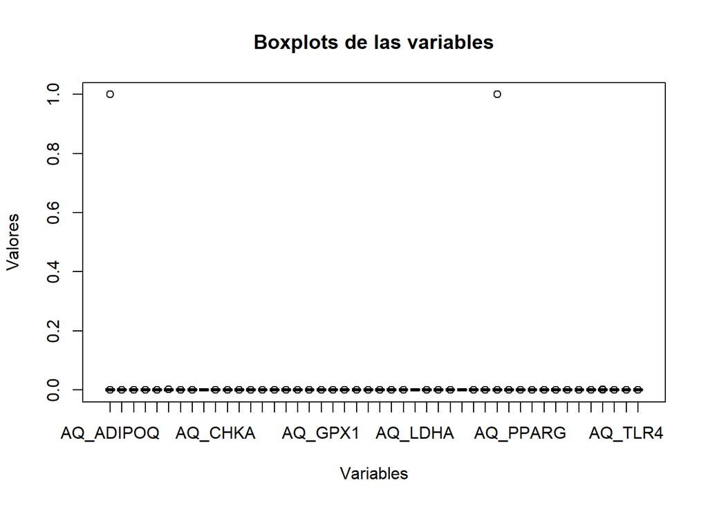

```r
boxplot(datos.genes,
        main = "Boxplots de las variables",
        xlab = "Variables",
        ylab = "Valores",
        col = "lightblue")
```

Podemos observar como ADIPOQ y NOX_5 tienen un único outlier con valor= 1.

Vamos a ver qué pacientes tienen este valor 1.

```r
which(datos.genes==1, arr.ind = TRUE)
```

```
##      row col
## [1,]  13   1
## [2,]  13  34
```

Vemos que es el mismo paciente, el 13.

Como hemos visto antes, este paciente tiene expresión génica=0 en 44 genes y expresión génica=1 en 2.

Esto nos impedirá obtener un análisis de PCA adecuado, ya que al tener tanta variabilidad, la PCA se va a centrar en únicamente en estos puntos y obtendremos un análisis sesgado.

Construimos un df sin el paciente 13 con el que vamos a realizar todo el trabajo.

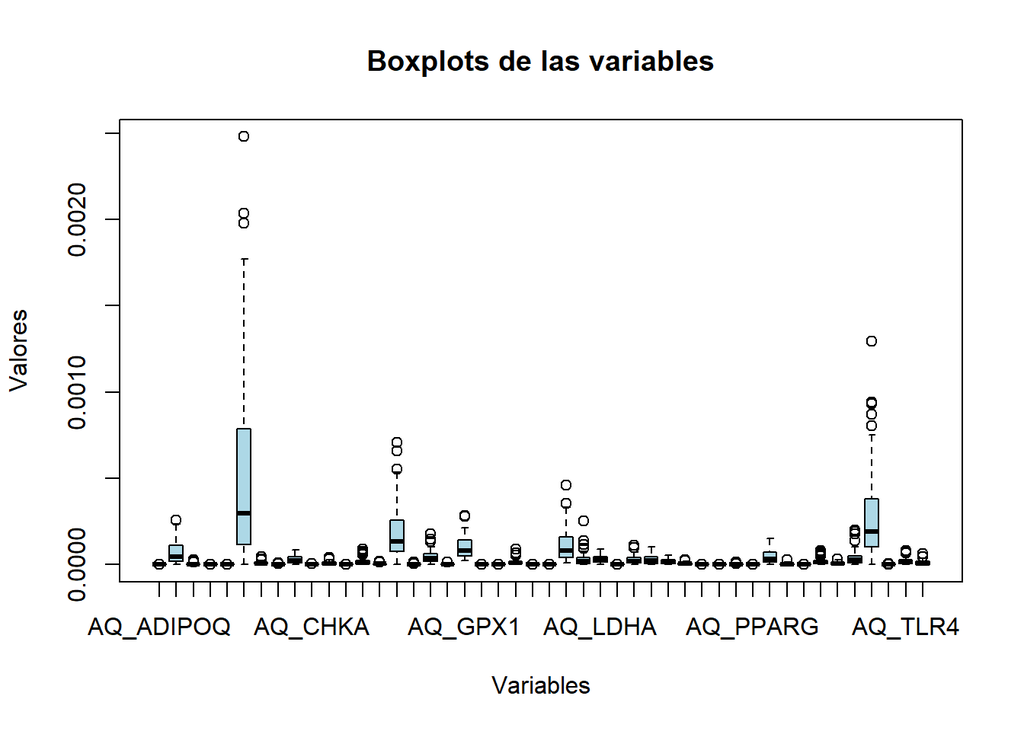

```r
datos.genes.def <- datos.genes [-13,]
boxplot(datos.genes.def,
        main = "Boxplots de las variables",
        xlab = "Variables",
        ylab = "Valores",
        col = "lightblue")
```

## 2. Aplicamos un PCA

Realizaremos un PCA, por ser una técnica rápida y sencilla, darnos la varianza explicada y tener una primera aproximación de los datos. Como desventaja es que asumimos correlación lineal de los datos antes de comprobar otra técnica y tener que buscar los componentes principales más significativos.

Para llevar a cabo la PCA usaremos: la funcion ‘prcomp()’ para calcular los componentes principales (a partir de ahora PC), ‘datos.genes’ como conjunto de datos, ‘center’ para que las variables esten centradas en cero y ‘scale’ porque queremos que las variables esten con varianza = 1.

El PCA se basa en la varianza, y sin escalar, los genes con mayor varianza dominarán las componentes principales.

El resultado sería un PCA que refleja principalmente las diferencias en unos pocos genes, ocultando patrones biológicos más sutiles en el resto.

```r
pca.results <- prcomp(datos.genes.def, center=TRUE, scale=TRUE)
summary(pca.results)
```

```
## Importance of components:
##                           PC1    PC2     PC3     PC4     PC5     PC6    PC7
## Standard deviation     4.9052 1.7931 1.61250 1.36943 1.32589 1.25525 1.1491
## Proportion of Variance 0.5231 0.0699 0.05653 0.04077 0.03822 0.03425 0.0287
## Cumulative Proportion  0.5231 0.5930 0.64949 0.69026 0.72848 0.76273 0.7914
##                            PC8     PC9    PC10    PC11    PC12    PC13    PC14
## Standard deviation     1.09704 0.99432 0.96706 0.89786 0.85984 0.78872 0.71494
## Proportion of Variance 0.02616 0.02149 0.02033 0.01752 0.01607 0.01352 0.01111
## Cumulative Proportion  0.81760 0.83909 0.85942 0.87694 0.89302 0.90654 0.91765
##                           PC15    PC16    PC17    PC18    PC19    PC20    PC21
## Standard deviation     0.67214 0.66472 0.65211 0.60108 0.54909 0.49618 0.47282
## Proportion of Variance 0.00982 0.00961 0.00924 0.00785 0.00655 0.00535 0.00486
## Cumulative Proportion  0.92747 0.93708 0.94632 0.95418 0.96073 0.96608 0.97094
##                          PC22    PC23    PC24    PC25    PC26    PC27    PC28
## Standard deviation     0.4500 0.38542 0.37315 0.34014 0.33343 0.30384 0.27875
## Proportion of Variance 0.0044 0.00323 0.00303 0.00252 0.00242 0.00201 0.00169
## Cumulative Proportion  0.9754 0.97858 0.98160 0.98412 0.98653 0.98854 0.99023
##                           PC29    PC30    PC31    PC32    PC33    PC34    PC35
## Standard deviation     0.26414 0.24575 0.22667 0.20925 0.20282 0.18800 0.16946
## Proportion of Variance 0.00152 0.00131 0.00112 0.00095 0.00089 0.00077 0.00062
## Cumulative Proportion  0.99175 0.99306 0.99418 0.99513 0.99602 0.99679 0.99742
##                           PC36    PC37    PC38    PC39    PC40    PC41    PC42
## Standard deviation     0.16215 0.13932 0.13183 0.12877 0.10657 0.10259 0.07477
## Proportion of Variance 0.00057 0.00042 0.00038 0.00036 0.00025 0.00023 0.00012
## Cumulative Proportion  0.99799 0.99841 0.99879 0.99915 0.99939 0.99962 0.99975
##                           PC43    PC44    PC45    PC46
## Standard deviation     0.06742 0.05619 0.04934 0.03989
## Proportion of Variance 0.00010 0.00007 0.00005 0.00003
## Cumulative Proportion  0.99984 0.99991 0.99997 1.00000
```

Después realizamos un data frame con los resultados de los PC, calculamos distintos parámetros relacionados con la varianza que nos ayudará a seleccionar los PC mas importantes y por último, averiguamos el numero de PC que expliquen el 70% de la varianza.

```r
pca.df <- data.frame(pca.results$x)

varianzas <- pca.results$sdev^2
total.varianza <- sum(varianzas)
varianza.explicada <- varianzas/total.varianza
varianza.acumulada <- cumsum(varianza.explicada)
print(varianza.acumulada)
```

```
##  [1] 0.5230656 0.5929651 0.6494904 0.6902584 0.7284754 0.7627288 0.7914334
##  [8] 0.8175963 0.8390891 0.8594196 0.8769446 0.8930169 0.9065404 0.9176523
## [15] 0.9274733 0.9370789 0.9463234 0.9541777 0.9607320 0.9660841 0.9709441
## [22] 0.9753464 0.9785756 0.9816025 0.9841176 0.9865345 0.9885415 0.9902306
## [29] 0.9917473 0.9930603 0.9941773 0.9951292 0.9960234 0.9967918 0.9974161
## [36] 0.9979877 0.9984096 0.9987874 0.9991479 0.9993947 0.9996235 0.9997451
## [43] 0.9998439 0.9999125 0.9999654 1.0000000
```

### Tabla PCA componentes y R^2

Hacemos una Tabla PCA con las componentes y R^2 y R^2 acomulada.

```r
componentes <- colnames(pca.results$x)
tabla_pca <- data.frame(Componente = componentes, R2 = varianza.explicada, "R2 acumulada" = varianza.acumulada)

print(tabla_pca)
```

```
##    Componente           R2 R2.acumulada
## 1         PC1 5.230656e-01    0.5230656
## 2         PC2 6.989953e-02    0.5929651
## 3         PC3 5.652533e-02    0.6494904
## 4         PC4 4.076794e-02    0.6902584
## 5         PC5 3.821700e-02    0.7284754
## 6         PC6 3.425339e-02    0.7627288
## 7         PC7 2.870467e-02    0.7914334
## 8         PC8 2.616285e-02    0.8175963
## 9         PC9 2.149287e-02    0.8390891
## 10       PC10 2.033046e-02    0.8594196
## 11       PC11 1.752495e-02    0.8769446
## 12       PC12 1.607233e-02    0.8930169
## 13       PC13 1.352356e-02    0.9065404
## 14       PC14 1.111183e-02    0.9176523
```

[output cut: 32 more lines]

```r
n.pc <- min(which(varianza.acumulada > 0.7))
print(n.pc)
```

```
## [1] 5
```

Vemos como las primeras 5 componentes principales explican el 70% de la varianza.

### Tabla PCA cargas.

Hacemos una tabla con las cargas del PCA.

```r
cargas <- pca.results$rotation
tabla_cargas <- data.frame(variables= rownames(cargas),cargas)
print(tabla_cargas)
```

```
##           variables        PC1          PC2          PC3          PC4
## AQ_ADIPOQ AQ_ADIPOQ 0.04800600 -0.141815771 -0.099194132  0.432840021
## AQ_ALOX5   AQ_ALOX5 0.16273965  0.099759539 -0.016214161  0.035584550
## AQ_ARG1     AQ_ARG1 0.05911666  0.302311863  0.210164017  0.186627198
## AQ_BMP2     AQ_BMP2 0.12111774  0.061365499  0.102114099 -0.027845683
## AQ_CCL2     AQ_CCL2 0.10788711 -0.282780490 -0.241687672  0.024495768
## AQ_CCL5     AQ_CCL5 0.18436777 -0.052959260  0.075906022  0.075859502
## AQ_CCR5     AQ_CCR5 0.17381172 -0.139354745  0.045385524 -0.051762226
## AQ_CD274   AQ_CD274 0.16248043  0.099187597  0.031455654 -0.029015392
## AQ_CD36     AQ_CD36 0.16255731  0.015213094  0.068872008 -0.151552220
## AQ_CHKA     AQ_CHKA 0.10916566 -0.174363352  0.243993351 -0.266385844
## AQ_CPT1A   AQ_CPT1A 0.16625484 -0.169492919  0.052972308  0.005564109
## AQ_CSF2     AQ_CSF2 0.09744430 -0.083491192 -0.046749251  0.055864696
## AQ_CXCR1   AQ_CXCR1 0.14081182  0.190939512 -0.044448392 -0.026599506
## AQ_FASN     AQ_FASN 0.17804410 -0.171365650 -0.015692613 -0.078479447
## AQ_FOXO3   AQ_FOXO3 0.11772648  0.007430341  0.305586076 -0.018846769
## AQ_FOXP3   AQ_FOXP3 0.14333933 -0.234556522 -0.218157708  0.213441646
## AQ_G6PD     AQ_G6PD 0.17001016  0.065087363  0.210637189  0.093309870
## AQ_GPD2     AQ_GPD2 0.15357813 -0.135788476  0.041613833 -0.295420123
## AQ_GPX1     AQ_GPX1 0.12489390  0.043930850  0.165862795  0.151834865
## AQ_IFNG     AQ_IFNG 0.16217525  0.005253613 -0.012383928 -0.232589646
## AQ_IL10     AQ_IL10 0.09975996  0.323147114 -0.165974546 -0.053701806
## AQ_IL1B     AQ_IL1B 0.15171387  0.185858579 -0.129084200  0.062700831
## AQ_IL6       AQ_IL6 0.12149366  0.054267977 -0.004062315 -0.067479704
## AQ_IRS1     AQ_IRS1 0.13535298 -0.135394594  0.057406755  0.338596007
## AQ_JAK1     AQ_JAK1 0.19081153 -0.088350802 -0.031839666  0.076686481
## AQ_JAK3     AQ_JAK3 0.13616035  0.241203964 -0.251002005 -0.103945071
## AQ_LDHA     AQ_LDHA 0.16678984 -0.061438223 -0.007431125  0.022525626
## AQ_LIF       AQ_LIF 0.11463183 -0.296419617 -0.001427758 -0.158158879
## AQ_MAPK1   AQ_MAPK1 0.17754502  0.050309672  0.153048472 -0.004852520
## AQ_NFE2L2 AQ_NFE2L2 0.18192396  0.001834412  0.031813676  0.155956475
## AQ_NFKB1   AQ_NFKB1 0.17802020 -0.010745243  0.051692020 -0.090706960
## AQ_NLRP3   AQ_NLRP3 0.17448864 -0.033150258 -0.098513207  0.027203383
## AQ_NOS2     AQ_NOS2 0.09802709  0.004319674 -0.291733753  0.079903859
## AQ_NOX5     AQ_NOX5 0.08081001  0.270589348 -0.271467577 -0.077722896
## AQ_PDCD1   AQ_PDCD1 0.15043722 -0.084567023 -0.019705125 -0.174656322
## AQ_PPARG   AQ_PPARG 0.14839836  0.155357353  0.096755682 -0.031532831
## AQ_PTAFR   AQ_PTAFR 0.18074268  0.128309458  0.071756127  0.013901727
## AQ_PTGS2   AQ_PTGS2 0.15333213  0.021771131  0.164300850  0.011157214
## AQ_SLC2A4 AQ_SLC2A4 0.01988898  0.155632391  0.361940674  0.275196559
```

[output cut: 415 more lines]

```
## AQ_NLRP3  -0.200769374  0.220237120
## AQ_NOS2   -0.093021618 -0.038051247
## AQ_NOX5    0.052645493  0.018543218
## AQ_PDCD1   0.015493670  0.103116410
## AQ_PPARG   0.240427766  0.001687312
## AQ_PTAFR   0.227921451 -0.368334293
## AQ_PTGS2   0.061757483 -0.071544881
## AQ_SLC2A4  0.012860742  0.012534270
## AQ_SOD1   -0.084605034  0.104029819
## AQ_SREBF1 -0.118208955  0.436011085
## AQ_STAT3   0.181333497  0.136682386
## AQ_TGFB1   0.167719029 -0.040020274
## AQ_TLR3   -0.159000176 -0.008204836
## AQ_TLR4    0.100192473  0.096251523
## AQ_TNF     0.105836374  0.109837760
```

## 3. Gráficos descriptivos de los PC

Representamos gráficamente las dos primeras PC de los datos, que explican el 59,30% de la varianza.

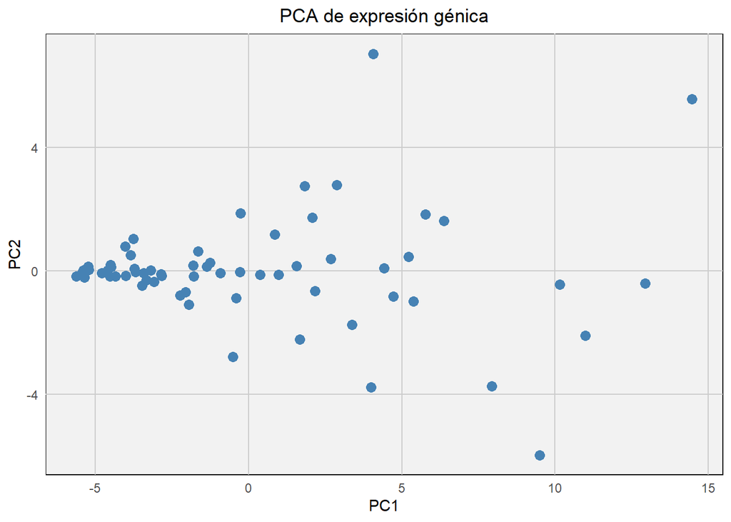

```r
pca_1_2 <- as.data.frame(pca.results$x[, 1:2])
colnames(pca_1_2) <- c("PC1", "PC2")

ggplot(pca_1_2, aes(x = PC1, y = PC2)) +
  geom_point(size = 3, color = "steelblue") +
  theme_minimal() +
  labs(title = "PCA de expresión génica", x = "PC1", y = "PC2")+
  theme(panel.grid.major = element_line(color="gray80"), panel.grid.minor = element_blank(),
        panel.background = element_rect(fill = "gray95"), plot.title = element_text(hjust = 0.5))
```

El objetivo de PCA es reducir la dimensionalidad de los datos y encontrar las combinaciones lineales de las variables originales que mejor explican la variabilidad en los datos.

PC1 y PC2 son las dos componentes principales que capturan la mayor variabilidad en la expresión génica entre los pacientes. PC1 explica más varianza que PC2.

PC1 separa a los pacientes a lo largo del eje horizontal. Los pacientes con valores más altos de PC1 (a la derecha) tienen patrones de expresión génica distintos de aquellos con valores más bajos de PC1 (a la izquierda).

PC2 separa a los pacientes a lo largo del eje vertical, aunque la separación parece menos pronunciada que con PC1.

Hay algunos puntos que se encuentran lejos del grupo principal, estos podrían ser pacientes atípicos con patrones de expresión génica inusuales.

Podemos también correlacionar las componentes principales con datos clínicos y hacer una distinción por grupos (tratamiento, tipo de tumor o extensión tumoral). De esta manera veríamos como se separan los distintos grupos en el espacio de las componentes.

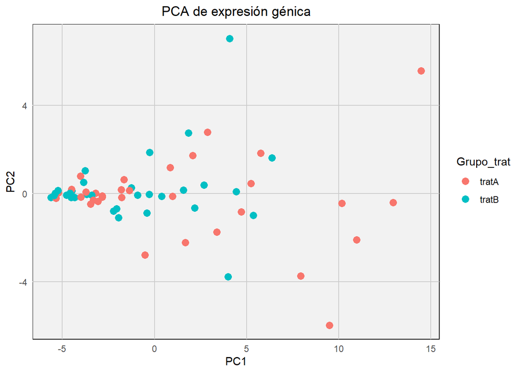

```r
Grupo_trat <- data$trat [-13]
ggplot(pca_1_2, aes(x = PC1, y = PC2, color= Grupo_trat)) +
  geom_point(size = 3) +
  theme_minimal() +
  labs(title = "PCA de expresión génica", x = "PC1", y = "PC2")+
  theme(panel.grid.major = element_line(color="gray80"), panel.grid.minor = element_blank(),
        panel.background = element_rect(fill = "gray95"), plot.title = element_text(hjust = 0.5))
```

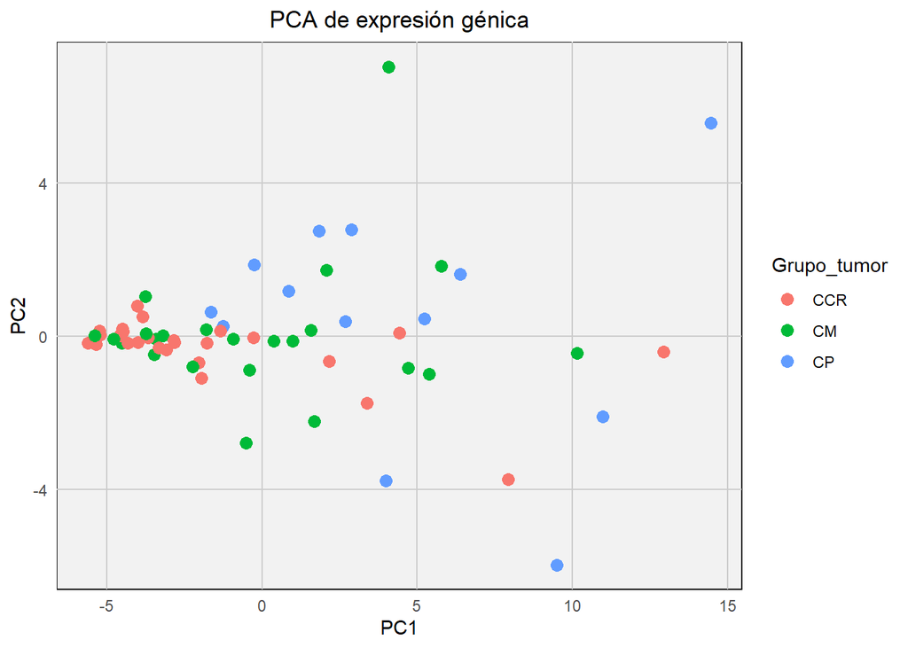

```r
Grupo_tumor <- data$tumor [-13]
ggplot(pca_1_2, aes(x = PC1, y = PC2, color= Grupo_tumor)) +
  geom_point(size = 3) +
  theme_minimal() +
  labs(title = "PCA de expresión génica", x = "PC1", y = "PC2")+
  theme(panel.grid.major = element_line(color="gray80"), panel.grid.minor = element_blank(),
        panel.background = element_rect(fill = "gray95"), plot.title = element_text(hjust = 0.5))
```

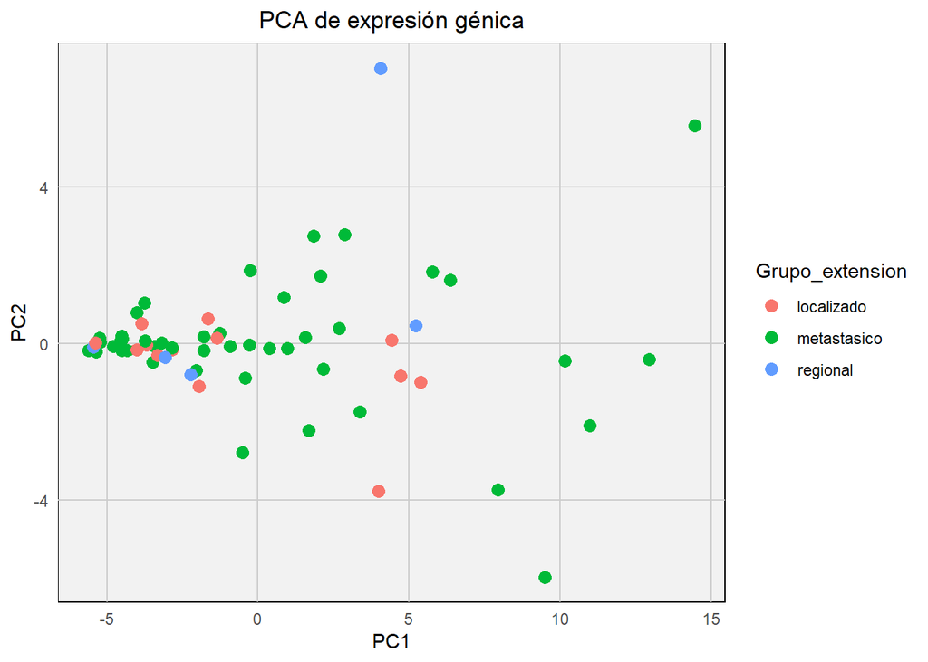

```r
Grupo_extension <- data$extension [-13]
ggplot(pca_1_2, aes(x = PC1, y = PC2, color= Grupo_extension)) +
  geom_point(size = 3) +
  theme_minimal() +
  labs(title = "PCA de expresión génica", x = "PC1", y = "PC2")+
  theme(panel.grid.major = element_line(color="gray80"), panel.grid.minor = element_blank(),
        panel.background = element_rect(fill = "gray95"), plot.title = element_text(hjust = 0.5))
```

Podemos observar como en ninguno de los tres casos las primeras dos componentes principales nos separan muy bien ninguno de los grupos estudiados.

Esto puede ocurrir porque la variabilidad entre los individuos es mayor que la diferencia inducida por el tratamiento, el tipo de tumor o la extensión.

Es necesario recordar que solo estamos visualizando las primeras dos componentes principales, eso quiere decir que podemos perder información porque no capturen la complejidad total de los datos.

## 4. Tablas descriptivas de los componentes principales (PC)

### Tabla de normalidad

```r
normalidad <- sapply(pca.df, function(x) {
    if (length(na.omit(x)) >= 3) {
    shapiro.test(x)$p.value
  } else {
    NA
  }
})
print(normalidad)
```

```
##          PC1          PC2          PC3          PC4          PC5          PC6
## 4.347486e-05 2.709424e-07 1.857264e-05 8.923859e-08 4.431559e-08 1.057103e-07
##          PC7          PC8          PC9         PC10         PC11         PC12
## 1.138879e-05 2.052729e-02 2.559630e-03 4.054880e-04 8.700739e-05 2.559253e-02
##         PC13         PC14         PC15         PC16         PC17         PC18
## 2.010964e-03 1.646726e-01 3.288888e-02 1.249964e-03 9.793987e-03 3.496011e-02
##         PC19         PC20         PC21         PC22         PC23         PC24
## 1.741729e-02 2.544391e-01 1.201931e-01 6.663629e-02 1.860587e-01 1.268676e-01
##         PC25         PC26         PC27         PC28         PC29         PC30
## 2.111989e-02 1.550515e-02 2.341234e-01 1.463907e-02 1.305773e-01 9.454232e-01
##         PC31         PC32         PC33         PC34         PC35         PC36
## 3.066095e-01 5.260609e-02 1.687627e-01 6.813656e-05 1.592866e-01 1.599104e-01
##         PC37         PC38         PC39         PC40         PC41         PC42
## 8.316779e-02 5.263023e-02 2.536785e-01 9.536884e-03 1.053157e-02 9.492278e-01
##         PC43         PC44         PC45         PC46
## 4.481176e-03 1.371101e-03 7.395221e-01 2.482964e-02
```

```r
normal <- normalidad > 0.05
```

Creamos una tabla que refleje los p-values y el test utilizado.

```r
normalidad_df <- data.frame(
  PC = names(normalidad),
  Test = "Shapiro-Wilk",
  P_value = normalidad,
  row.names = NULL
)
```

Añadir interpretación

```r
normalidad_df$Interpretacion <- ifelse(
  is.na(normalidad_df$P_value),
  "No evaluado (datos insuficientes)",
  ifelse(normalidad_df$P_value >= 0.05,
         "Distribución normal",
         "No sigue distribución normal")
)
print(normalidad_df)
```

```
##      PC         Test      P_value               Interpretacion
## 1   PC1 Shapiro-Wilk 4.347486e-05 No sigue distribución normal
## 2   PC2 Shapiro-Wilk 2.709424e-07 No sigue distribución normal
## 3   PC3 Shapiro-Wilk 1.857264e-05 No sigue distribución normal
## 4   PC4 Shapiro-Wilk 8.923859e-08 No sigue distribución normal
## 5   PC5 Shapiro-Wilk 4.431559e-08 No sigue distribución normal
## 6   PC6 Shapiro-Wilk 1.057103e-07 No sigue distribución normal
## 7   PC7 Shapiro-Wilk 1.138879e-05 No sigue distribución normal
## 8   PC8 Shapiro-Wilk 2.052729e-02 No sigue distribución normal
## 9   PC9 Shapiro-Wilk 2.559630e-03 No sigue distribución normal
## 10 PC10 Shapiro-Wilk 4.054880e-04 No sigue distribución normal
## 11 PC11 Shapiro-Wilk 8.700739e-05 No sigue distribución normal
## 12 PC12 Shapiro-Wilk 2.559253e-02 No sigue distribución normal
## 13 PC13 Shapiro-Wilk 2.010964e-03 No sigue distribución normal
## 14 PC14 Shapiro-Wilk 1.646726e-01          Distribución normal
```

[output cut: 32 more lines]

Separación en 2 df según normalidad

```r
genes_normales <- normalidad_df %>% filter(Interpretacion == "Distribución normal")
genes_no.normales <- normalidad_df %>% filter(Interpretacion == "No sigue distribución normal")
```

Hacer Tabla por terciles de cada PCA, en función de si sigue o no una distribución normal elegimos un contraste de hipótesis.

```r
tabla_terciles <- function(pca.df, PCAs, tipo = "no_parametrica", tercil.labels = c("t1", "t2", "t3")){
  df_PCA <- pca.df %>%
    select(all_of(PCAs)) %>%
    rename(point = all_of(PCAs))
  cortes <- quantile(df_PCA$point, probs = c(0, 1/3, 2/3, 1), na.rm =TRUE)

  df_PCA <- df_PCA %>%
    mutate(tercil = cut(point, breaks = cortes, include.lowest = TRUE, labels = tercil.labels))

if (tipo == "parametrica"){
  tabla <- df_PCA %>%
    tbl_summary(
      by=tercil,
      statistic = all_continuous()~ "{mean} ({sd})",
      digits = all_continuous()~1,
      missing="no"
    ) %>%
    add_p(test = all_continuous()~"oneway.test",
          test.args = all_continuous() ~ list(var.equal = TRUE),
          pvalue_fun = ~style_pvalue(.x, digits = 3))
} else {
  tabla <- df_PCA %>%
    tbl_summary(
      by=tercil,
      statistic = all_continuous() ~ "{median} ({IQR})",
      digits= all_continuous()~1,
      missing= "no"
    ) %>%
    add_p(test = all_continuous()~ "kruskal.test", pvalue_fun= ~style_pvalue(.x, digits=3))
}
  tabla <- tabla %>%
    modify_header(label ~ paste0("**", PCAs, "**")) %>%
    modify_spanning_header(all_stat_cols() ~ glue::glue("**Distribución de {PCAs} por Tercil**"))

return(tabla)
}

lista_tablas <- list()

for (pc in genes_normales$PC) {
  lista_tablas[[pc]] <- tabla_terciles(pca.df, PCAs = pc, tipo = "parametrica")
}

for (pc in genes_no.normales$PC) {
  lista_tablas[[pc]] <- tabla_terciles(pca.df, PCAs = pc, tipo = "no_parametrica")
}
```

Aquí obtenemos las tablas descriptivas de todos los componentes, vamos a filtrar los más importantes, que son los que hemos seleccionado a partir de que expliquen el 70% de la varianza. Justo estas 5 siguen una distribución no normal.

```r
pcas_importantes <- paste0("PC", 1:n.pc)
lista_tablas_70 <- lista_tablas[pcas_importantes] #Filtramos las tablas descriptivas úncamente de los componentes "importantes".
```

Ahora unimos las 5 tbl_summarys en una sola mediante el comando tbl_stack de gtsummarys y manteniendo el group_header de cada una de ellas.

### Tabla de la distribución por terciles de los PCs

```r
tabla_70_combinadas <- tbl_stack(
  tbls = lista_tablas_70, #indicamos que queremos unir las tablas contenidas en lista_tablas_70
  group_header = names(lista_tablas_70), #especificamos que queremos mantener el nombre de cada una de ellas
  ) %>%
  modify_header( label ~ "**PCs**") %>%
  modify_spanning_header(all_stat_cols() ~ ("**Distribución de PCs por Tercil**"))
```

```
## Column headers among stacked tables differ. Headers from the first table are
## used.
## ℹ Check the header is correct and use `modify_header()` to update, or `quiet =
##   TRUE` to suppress this message.
```

```r
tabla_70_combinadas
```

[output not shown]

<sup>1</sup> Median (IQR)  
<sup>2</sup> Kruskal-Wallis rank sum test

Volviendo a observar lo que se nos pide en la actividad nos damos cuenta que no hemos realizado lo que se nos ha pedido. Volvemos a empezar y a organizar nuestros datos. Ahora vamos a utilizar las librerías FactoMineR y factoextra, que son las que se utiliza en el ejemplo adjunto de la actividad de RPubs.

```r
library(FactoMineR)
library(factoextra)
```

Vamos a volver a hacer los PCA de los genes, ahora con el comando PCA() de FactoMineR; en este caso a diferencia de prcomp(), por defecto se nos muestra únicamente los 5 primeros componentes, en nuestro caso no nos importa ya que son justamente los que habíamos visto que explicaban más del 70% de la varianza (si quisieramos observar más componentes lo podríamos haber editado con npc = “nºPCs”.

```r
resultados.pca <- PCA(datos.genes.def, scale.unit = TRUE, graph = FALSE)
res.pca.df <- as.data.frame(resultados.pca$ind$coord)
```

Ahora vamos a crear los terciles para los 5 primeros PCs, que son los que habíamos visto que explicaban el 70% de la varianza.

```r
for(i in 1:5){
  nombre_pc <- paste0("Dim.", i)
  nombre_tercil <- paste0("tercil_PC", i)
  res.pca.df[[nombre_tercil]] <- cut(
    res.pca.df[[nombre_pc]],
    breaks = quantile(res.pca.df[[nombre_pc]], probs= c(0, 1/3, 2/3, 1), na.rm= TRUE),
    include.lowest = TRUE, labels = c("T1", "T2", "T3")
  )
}
```

Ahora vamos a unir los terciles de los PCs con los datos originales. Para poder unir el data original con el generado tenemos que retirar la observación 13, para que coincidan en filas.

```r
data.clean <- data[-13,]
data.tot <- bind_cols(data.clean, res.pca.df[,grep("tercil_PC", names(res.pca.df))])
```

Ahora ya tenemos los datos unidos en un mismo data.frame. Vamos a generar las tablas descriptivas. La actividad nos dice que los descriptivos los mostremos en funci´´on de si las variables son parámetricas o no, por tanto tendremos que comprobar normalidad con Shapiro-Wilks, y separar los genes en dos conjuntos diferentes (los parámetricos y los no parámetricos) y a partir de ahí hacer 2 tablas diferentes para poder comparar entre ellos.

```r
#Vamos a valorar la normalidad de los genes.
genes_nombres <- colnames(datos.genes.def)
p_values <- sapply(genes_nombres, function(g) shapiro.test(data.clean[[g]])$p.value)
test.norm <- data.frame(
  gen = genes_nombres,
  p_value = p_values,
  normal = p_values > 0.05,
  stringsAsFactors = FALSE
)
print(test.norm)
```

```
##                 gen      p_value normal
## AQ_ADIPOQ AQ_ADIPOQ 2.942191e-16  FALSE
## AQ_ALOX5   AQ_ALOX5 1.091293e-06  FALSE
## AQ_ARG1     AQ_ARG1 4.573177e-10  FALSE
## AQ_BMP2     AQ_BMP2 8.007204e-09  FALSE
## AQ_CCL2     AQ_CCL2 2.144934e-12  FALSE
## AQ_CCL5     AQ_CCL5 1.657507e-07  FALSE
## AQ_CCR5     AQ_CCR5 9.383516e-09  FALSE
## AQ_CD274   AQ_CD274 7.921574e-08  FALSE
## AQ_CD36     AQ_CD36 1.617997e-04  FALSE
## AQ_CHKA     AQ_CHKA 1.890277e-06  FALSE
## AQ_CPT1A   AQ_CPT1A 1.508928e-06  FALSE
## AQ_CSF2     AQ_CSF2 9.141639e-09  FALSE
## AQ_CXCR1   AQ_CXCR1 1.280270e-08  FALSE
## AQ_FASN     AQ_FASN 2.376266e-06  FALSE
## AQ_FOXO3   AQ_FOXO3 2.579805e-06  FALSE
## AQ_FOXP3   AQ_FOXP3 2.628306e-11  FALSE
## AQ_G6PD     AQ_G6PD 3.901170e-06  FALSE
## AQ_GPD2     AQ_GPD2 1.223418e-07  FALSE
## AQ_GPX1     AQ_GPX1 6.252962e-05  FALSE
## AQ_IFNG     AQ_IFNG 1.135168e-08  FALSE
## AQ_IL10     AQ_IL10 1.580977e-13  FALSE
## AQ_IL1B     AQ_IL1B 2.345771e-09  FALSE
## AQ_IL6       AQ_IL6 7.170283e-12  FALSE
## AQ_IRS1     AQ_IRS1 1.946397e-06  FALSE
## AQ_JAK1     AQ_JAK1 2.874972e-06  FALSE
## AQ_JAK3     AQ_JAK3 6.485848e-11  FALSE
## AQ_LDHA     AQ_LDHA 8.849561e-05  FALSE
## AQ_LIF       AQ_LIF 1.781381e-10  FALSE
## AQ_MAPK1   AQ_MAPK1 3.773467e-05  FALSE
## AQ_NFE2L2 AQ_NFE2L2 2.525432e-06  FALSE
## AQ_NFKB1   AQ_NFKB1 2.211272e-04  FALSE
## AQ_NLRP3   AQ_NLRP3 1.742192e-06  FALSE
## AQ_NOS2     AQ_NOS2 8.604047e-12  FALSE
## AQ_NOX5     AQ_NOX5 2.031714e-13  FALSE
## AQ_PDCD1   AQ_PDCD1 8.367907e-12  FALSE
## AQ_PPARG   AQ_PPARG 4.156289e-11  FALSE
## AQ_PTAFR   AQ_PTAFR 8.545875e-06  FALSE
## AQ_PTGS2   AQ_PTGS2 9.479094e-08  FALSE
## AQ_SLC2A4 AQ_SLC2A4 4.506437e-11  FALSE
## AQ_SOD1     AQ_SOD1 4.645161e-07  FALSE
## AQ_SREBF1 AQ_SREBF1 4.463598e-05  FALSE
## AQ_STAT3   AQ_STAT3 1.579483e-09  FALSE
## AQ_TGFB1   AQ_TGFB1 2.389690e-07  FALSE
## AQ_TLR3     AQ_TLR3 7.962986e-11  FALSE
## AQ_TLR4     AQ_TLR4 5.663507e-06  FALSE
## AQ_TNF       AQ_TNF 1.121548e-07  FALSE
```

Si observamos “test.norm” observamos como los 46 genes siguen una distribución no normal por lo que en las tablas descriptivas que queremos hacer podemos mostrar directamente mediana e IQR y aplicar Kruskal-Wallis (k>3, porque tenemos 3 subgrupos por terciles), haciendo por tanto una única tabla para todos los genes y PC1-PC5. Creamos una lista y la vamos rellenando con un bucle for.

```r
lista_genes <- grep("^AQ_", names(data.tot), value=TRUE)


tabla_def <- list()

for (i in 1:5){
  tercil_col <- paste0("tercil_PC", i)
  tabla_def[[i]] <- data.tot %>%
    select(all_of(lista_genes), all_of(tercil_col)) %>%
    tbl_summary(
      by= all_of(tercil_col),
      statistic = all_continuous() ~ "{median} ({p25} - {p75})",
      digits = all_continuous() ~ function(x) format(x, digits=3, scientific= TRUE))%>%
    add_p(test= all_continuous() ~ "kruskal.test") %>%
    modify_header( label ~ "**Gen**") %>%
    modify_caption(paste0("**Descriptiva por terciles PC**"))

}
```

Unimos las tablas con tbl_merge y configuramos formato para que se vea un poco mejor.

```r
tabla_combinada <- tbl_merge(
  tbls = tabla_def,
  tab_spanner = paste0("**PC", 1:5,"**")
)
tabla_combinada %>%
  as_flex_table() %>%
  flextable::fontsize(size = 7, part = "all") %>%
  flextable::set_table_properties(width = .75, layout = "autofit") %>%
  flextable::padding(padding = 1, part = "all") %>%
  flextable::line_spacing(space = 0.8) %>%
  flextable::align(align = "center", part = "all")
```

**Descriptiva por terciles PC**

| Gen | PC1 T1 N = 221 | PC1 T2 N = 211 | PC1 T3 N = 211 | PC1 p-value2 | PC2 T1 N = 221 | PC2 T2 N = 211 | PC2 T3 N = 211 | PC2 p-value2 | PC3 T1 N = 221 | PC3 T2 N = 211 | PC3 T3 N = 211 | PC3 p-value2 | PC4 T1 N = 221 | PC4 T2 N = 211 | PC4 T3 N = 211 | PC4 p-value2 | PC5 T1 N = 221 | PC5 T2 N = 211 | PC5 T3 N = 211 | PC5 p-value2 |
| --- | --- | --- | --- | --- | --- | --- | --- | --- | --- | --- | --- | --- | --- | --- | --- | --- | --- | --- | --- | --- |
| AQ_ADIPOQ | 3.91e-10 (0e+00 - 4.94e-10) | 0e+00 (0e+00 - 6.09e-10) | 1.42e-09 (0e+00 - 2.27e-09) | 0.033 | 3.46e-10 (0e+00 - 1.56e-09) | 3.76e-10 (0e+00 - 5.25e-10) | 5.61e-10 (0e+00 - 1.26e-09) | 0.4 | 4.62e-10 (3.13e-10 - 1.16e-09) | 0e+00 (0e+00 - 5.31e-10) | 0e+00 (0e+00 - 1.62e-09) | 0.2 | 4.34e-10 (0e+00 - 1.16e-09) | 3.13e-10 (0e+00 - 4.37e-10) | 5.61e-10 (0e+00 - 1.62e-09) | 0.2 | 0e+00 (0e+00 - 5.25e-10) | 3.79e-10 (0e+00 - 5.17e-10) | 1.15e-09 (4.26e-10 - 1.62e-09) | 0.004 |
| AQ_ALOX5 | 1.83e-05 (1.41e-05 - 3.19e-05) | 4e-05 (2.14e-05 - 6.97e-05) | 1.42e-04 (8.45e-05 - 1.9e-04) | <0.001 | 5.3e-05 (1.99e-05 - 1.16e-04) | 2.66e-05 (1.6e-05 - 3.67e-05) | 8.45e-05 (4.43e-05 - 1.42e-04) | 0.006 | 7.08e-05 (2.18e-05 - 1.16e-04) | 2.14e-05 (1.5e-05 - 4e-05) | 6.07e-05 (3.67e-05 - 1.42e-04) | 0.005 | 5.85e-05 (2.14e-05 - 1.42e-04) | 3.01e-05 (1.67e-05 - 4.43e-05) | 6.07e-05 (2.05e-05 - 1.21e-04) | 0.078 | 4.46e-05 (1.99e-05 - 7.98e-05) | 2.18e-05 (1.6e-05 - 3.78e-05) | 1.14e-04 (6.07e-05 - 1.76e-04) | <0.001 |
| AQ_ARG1 | 1.01e-06 (5.2e-07 - 1.64e-06) | 2.59e-06 (1.31e-06 - 3.27e-06) | 5.04e-06 (2.3e-06 - 8.18e-06) | 0.004 | 1.31e-06 (5.2e-07 - 2.59e-06) | 1.14e-06 (6.69e-07 - 3.15e-06) | 5.88e-06 (2.79e-06 - 1.01e-05) | <0.001 | 1.07e-06 (5.2e-07 - 2.12e-06) | 1.42e-06 (7.35e-07 - 3.08e-06) | 5.24e-06 (3.14e-06 - 8.18e-06) | <0.001 | 2.31e-06 (1.14e-06 - 4.24e-06) | 8.68e-07 (5.2e-07 - 2.79e-06) | 3.15e-06 (1.53e-06 - 6.94e-06) | 0.030 | 4.57e-06 (1.31e-06 - 1.01e-05) | 8.68e-07 (5.2e-07 - 2.68e-06) | 3.15e-06 (1.53e-06 - 5.04e-06) | 0.002 |
| AQ_BMP2 | 1.33e-08 (5.66e-09 - 2.17e-08) | 2.98e-08 (2.01e-08 - 4.44e-08) | 9.1e-08 (5.8e-08 - 1.4e-07) | <0.001 | 4.24e-08 (2.65e-08 - 9.1e-08) | 1.41e-08 (7.18e-09 - 2.79e-08) | 3.75e-08 (2.61e-08 - 7.78e-08) | 0.010 | 3.42e-08 (1.41e-08 - 6.35e-08) | 2.65e-08 (9.23e-09 - 3.91e-08) | 4.45e-08 (2.61e-08 - 1.4e-07) | 0.092 | 5.6e-08 (2.94e-08 - 7.88e-08) | 1.93e-08 (6.01e-09 - 3.57e-08) | 2.88e-08 (1.41e-08 - 1.02e-07) | 0.006 | 5.12e-08 (2.86e-08 - 1.54e-07) | 1.29e-08 (5.43e-09 - 2.88e-08) | 3.57e-08 (1.93e-08 - 7.88e-08) | <0.001 |
| AQ_CCL2 | 1.08e-08 (5.64e-09 - 2.06e-08) | 5.51e-08 (2.37e-08 - 1.09e-07) | 1.5e-07 (6.01e-08 - 2.71e-07) | <0.001 | 1.11e-07 (4.71e-08 - 2.43e-07) | 2.06e-08 (8.64e-09 - 4.34e-08) | 3.55e-08 (1.54e-08 - 1.09e-07) | 0.006 | 4.73e-08 (2.06e-08 - 2.43e-07) | 1.91e-08 (1.07e-08 - 3.83e-08) | 5.95e-08 (2.53e-08 - 1.5e-07) | 0.087 | 6.51e-08 (4.34e-08 - 1.83e-07) | 1.91e-08 (1.06e-08 - 5.2e-08) | 3.55e-08 (6.41e-09 - 9.26e-08) | 0.016 | 5.26e-08 (2.37e-08 - 1.83e-07) | 1.72e-08 (7.58e-09 - 4.34e-08) | 1.09e-07 (2.53e-08 - 2.35e-07) | 0.002 |
| AQ_CCL5 | 1.09e-04 (7.76e-05 - 1.8e-04) | 3.81e-04 (2.68e-04 - 5.99e-04) | 9.16e-04 (7.84e-04 - 1.3e-03) | <0.001 | 4.27e-04 (1.82e-04 - 1.3e-03) | 1.83e-04 (7.76e-05 - 2.89e-04) | 4.9e-04 (2.68e-04 - 7.84e-04) | 0.014 | 3.93e-04 (1.11e-04 - 5.99e-04) | 1.95e-04 (9.56e-05 - 2.68e-04) | 7.84e-04 (3.81e-04 - 1.15e-03) | 0.001 | 4.27e-04 (2.39e-04 - 9.16e-04) | 1.53e-04 (8.22e-05 - 2.28e-04) | 5.77e-04 (1.45e-04 - 8.47e-04) | 0.002 | 4.15e-04 (1.99e-04 - 7.84e-04) | 1.11e-04 (7.76e-05 - 2.68e-04) | 6.12e-04 (1.95e-04 - 1.15e-03) | <0.001 |
| AQ_CCR5 | 1.8e-06 (1.08e-06 - 3.69e-06) | 6.66e-06 (5.07e-06 - 7.61e-06) | 1.85e-05 (8.43e-06 - 2.37e-05) | <0.001 | 1.05e-05 (5.52e-06 - 2.05e-05) | 3.66e-06 (1.31e-06 - 5.84e-06) | 5.58e-06 (3.2e-06 - 8.43e-06) | 0.001 | 6.89e-06 (3.91e-06 - 1.25e-05) | 3.75e-06 (1.31e-06 - 5.52e-06) | 8.43e-06 (5.13e-06 - 2.06e-05) | 0.005 | 8.06e-06 (5.52e-06 - 1.98e-05) | 3.2e-06 (1.13e-06 - 5.58e-06) | 6.66e-06 (3.66e-06 - 1.5e-05) | <0.001 | 7.39e-06 (5.07e-06 - 1.21e-05) | 3.49e-06 (1.12e-06 - 4.22e-06) | 7.06e-06 (5.37e-06 - 2.37e-05) | <0.001 |
| AQ_CD274 | 4.64e-07 (3.3e-07 - 8e-07) | 1.31e-06 (1.03e-06 - 1.77e-06) | 3.08e-06 (2.83e-06 - 3.55e-06) | <0.001 | 1.77e-06 (7.33e-07 - 2.96e-06) | 8.28e-07 (4.8e-07 - 1.07e-06) | 1.72e-06 (1.03e-06 - 3.54e-06) | 0.035 | 1.57e-06 (5.8e-07 - 2.65e-06) | 1.03e-06 (4.85e-07 - 1.62e-06) | 1.72e-06 (1.04e-06 - 3.48e-06) | 0.040 | 1.73e-06 (1.09e-06 - 2.96e-06) | 7.33e-07 (3.56e-07 - 1.62e-06) | 1.36e-06 (6.9e-07 - 3.09e-06) | 0.036 | 1.92e-06 (1.03e-06 - 3.55e-06) | 5.95e-07 (3.41e-07 - 1.09e-06) | 2.01e-06 (1.34e-06 - 3.09e-06) | <0.001 |
| AQ_CD36 | 7.73e-06 (4.28e-06 - 9.96e-06) | 2.63e-05 (1.67e-05 - 3.79e-05) | 5e-05 (3.1e-05 - 6.67e-05) | <0.001 | 3.04e-05 (1.67e-05 - 5.14e-05) | 9.96e-06 (8.34e-06 - 1.72e-05) | 2.75e-05 (1.73e-05 - 5.4e-05) | 0.004 | 2.28e-05 (9.28e-06 - 3.1e-05) | 1.13e-05 (8.34e-06 - 2.28e-05) | 3.97e-05 (2.64e-05 - 5.4e-05) | 0.005 | 4.77e-05 (1.7e-05 - 6.01e-05) | 9.51e-06 (7.13e-06 - 1.73e-05) | 2.66e-05 (1.49e-05 - 3.58e-05) | <0.001 | 2.82e-05 (1.7e-05 - 4.65e-05) | 8.44e-06 (4.28e-06 - 1.45e-05) | 4.47e-05 (2.63e-05 - 7.35e-05) | <0.001 |
| AQ_CHKA | 2.16e-07 (1.03e-07 - 3.01e-07) | 6.39e-07 (4.54e-07 - 1.04e-06) | 1.25e-06 (5.08e-07 - 1.9e-06) | 0.001 | 1.2e-06 (2.75e-07 - 1.9e-06) | 2.16e-07 (9.94e-08 - 3.91e-07) | 6.9e-07 (4.27e-07 - 9.75e-07) | 0.003 | 2.27e-07 (0e+00 - 5.2e-07) | 3.43e-07 (2e-07 - 8.78e-07) | 9.68e-07 (6.39e-07 - 1.7e-06) | 0.002 | 1.24e-06 (4.3e-07 - 1.9e-06) | 2.19e-07 (1.03e-07 - 5.22e-07) | 4.54e-07 (0e+00 - 9.21e-07) | 0.002 | 8.35e-07 (3.91e-07 - 1.33e-06) | 2.16e-07 (1.03e-07 - 4.54e-07) | 9.21e-07 (0e+00 - 1.9e-06) | 0.006 |
| AQ_CPT1A | 1.94e-06 (1.29e-06 - 3.37e-06) | 5.6e-06 (4.36e-06 - 9.94e-06) | 1.8e-05 (1.2e-05 - 2.42e-05) | <0.001 | 9.61e-06 (4.27e-06 - 2.39e-05) | 3.37e-06 (1.85e-06 - 4.77e-06) | 8.51e-06 (3.48e-06 - 1.32e-05) | 0.011 | 5.18e-06 (1.49e-06 - 1.13e-05) | 3.37e-06 (1.85e-06 - 8.36e-06) | 1.2e-05 (5e-06 - 2.19e-05) | 0.004 | 9.61e-06 (5.17e-06 - 2.02e-05) | 2.69e-06 (1.25e-06 - 4.47e-06) | 7.13e-06 (3.59e-06 - 1.53e-05) | 0.001 | 7.37e-06 (3.63e-06 - 1.03e-05) | 1.85e-06 (1.25e-06 - 4.27e-06) | 1.34e-05 (5e-06 - 2.39e-05) | <0.001 |
| AQ_CSF2 | 1.12e-09 (4.11e-10 - 1.5e-08) | 2.24e-08 (7.85e-09 - 4.66e-08) | 2.67e-08 (1.04e-08 - 7.37e-08) | 0.009 | 3.3e-08 (3.22e-09 - 8.73e-08) | 6.01e-09 (4.11e-10 - 2.39e-08) | 1.53e-08 (4.12e-10 - 2.87e-08) | 0.040 | 1.47e-08 (1.16e-09 - 4.66e-08) | 1.29e-08 (4.94e-10 - 2.7e-08) | 1.54e-08 (0e+00 - 6.45e-08) | 0.9 | 2.89e-08 (1.25e-08 - 7.26e-08) | 1.68e-09 (0e+00 - 1.5e-08) | 1.69e-08 (5.61e-10 - 3.37e-08) | 0.008 | 3.66e-08 (1.29e-08 - 9.76e-08) | 2.12e-09 (4.11e-10 - 2.24e-08) | 1.04e-08 (5.61e-10 - 2.87e-08) | 0.007 |
| AQ_CXCR1 | 4.72e-06 (2.99e-06 - 6.06e-06) | 1e-05 (7.8e-06 - 1.53e-05) | 3.71e-05 (1.87e-05 - 5.7e-05) | <0.001 | 1.21e-05 (7.71e-06 - 2.56e-05) | 4.86e-06 (4.12e-06 - 8.05e-06) | 2e-05 (9.24e-06 - 4.4e-05) | 0.002 | 9.23e-06 (5.01e-06 - 2.4e-05) | 4.86e-06 (4.43e-06 - 1.02e-05) | 2e-05 (8.05e-06 - 3.83e-05) | 0.059 | 1.11e-05 (7.8e-06 - 3.71e-05) | 4.79e-06 (3.01e-06 - 9.24e-06) | 1.32e-05 (7.25e-06 - 2.56e-05) | 0.026 | 1.26e-05 (9.24e-06 - 2.94e-05) | 4.79e-06 (3.01e-06 - 7.71e-06) | 1.36e-05 (6e-06 - 3.71e-05) | 0.010 |
| AQ_FASN | 6.27e-07 (3.35e-07 - 1.25e-06) | 3.58e-06 (2.56e-06 - 4.24e-06) | 7.56e-06 (5.1e-06 - 1.19e-05) | <0.001 | 6.34e-06 (2.87e-06 - 1.02e-05) | 1.24e-06 (5.41e-07 - 2.56e-06) | 3.22e-06 (1.91e-06 - 4.91e-06) | <0.001 | 3.13e-06 (1.51e-06 - 6.02e-06) | 1.24e-06 (5.41e-07 - 3.04e-06) | 4.28e-06 (3.6e-06 - 7.43e-06) | 0.008 | 3.96e-06 (2.87e-06 - 9.76e-06) | 1.24e-06 (5.12e-07 - 2.48e-06) | 3.62e-06 (1.24e-06 - 6.36e-06) | 0.002 | 3.61e-06 (1.91e-06 - 5.39e-06) | 1.03e-06 (5.12e-07 - 2.48e-06) | 5.1e-06 (2.56e-06 - 9.76e-06) | <0.001 |
| AQ_FOXO3 | 8.35e-05 (4.62e-05 - 1.26e-04) | 1.12e-04 (6.57e-05 - 2.55e-04) | 2.7e-04 (1.62e-04 - 3.39e-04) | <0.001 | 1.36e-04 (6.57e-05 - 2.7e-04) | 9.98e-05 (7.69e-05 - 1.5e-04) | 1.98e-04 (9.83e-05 - 2.55e-04) | 0.5 | 7.49e-05 (4.19e-05 - 1.54e-04) | 1.12e-04 (9.16e-05 - 1.5e-04) | 2.75e-04 (2.48e-04 - 3.86e-04) | <0.001 | 1.61e-04 (8.49e-05 - 2.7e-04) | 8.73e-05 (4.62e-05 - 1.43e-04) | 1.85e-04 (9.98e-05 - 3.34e-04) | 0.046 | 1.15e-04 (4.45e-05 - 2.48e-04) | 8.49e-05 (6.43e-05 - 1.43e-04) | 2.7e-04 (1.5e-04 - 3.59e-04) | 0.003 |
| AQ_FOXP3 | 2.57e-07 (1.1e-07 - 4.53e-07) | 1.31e-06 (7.62e-07 - 1.57e-06) | 2.96e-06 (1.42e-06 - 4.24e-06) | <0.001 | 1.96e-06 (1.06e-06 - 4.21e-06) | 4.82e-07 (1.16e-07 - 8.41e-07) | 1.05e-06 (2.72e-07 - 1.39e-06) | <0.001 | 1.37e-06 (2.13e-07 - 2.1e-06) | 5.28e-07 (2.61e-07 - 7.08e-07) | 1.42e-06 (9.66e-07 - 1.9e-06) | 0.036 | 1.26e-06 (6.93e-07 - 2.96e-06) | 2.61e-07 (9.19e-08 - 1.31e-06) | 1.42e-06 (5.6e-07 - 1.98e-06) | 0.001 | 1.25e-06 (5.6e-07 - 1.69e-06) | 3.47e-07 (1.1e-07 - 7.66e-07) | 1.57e-06 (8.41e-07 - 3.51e-06) | <0.001 |
| AQ_G6PD | 1.4e-05 (9.87e-06 - 1.9e-05) | 3.61e-05 (2.79e-05 - 4.15e-05) | 7.14e-05 (6e-05 - 8.86e-05) | <0.001 | 3.84e-05 (2.35e-05 - 7.14e-05) | 1.71e-05 (1.2e-05 - 2.99e-05) | 4.55e-05 (3.41e-05 - 7e-05) | 0.002 | 3.84e-05 (1.78e-05 - 6e-05) | 1.68e-05 (1.2e-05 - 2.6e-05) | 5.04e-05 (3.74e-05 - 8.55e-05) | <0.001 | 3.56e-05 (2.35e-05 - 7.89e-05) | 1.58e-05 (1.2e-05 - 3.61e-05) | 4.87e-05 (2.99e-05 - 7e-05) | 0.004 | 3.58e-05 (2.35e-05 - 5.04e-05) | 1.31e-05 (9.87e-06 - 2.8e-05) | 6.36e-05 (3.46e-05 - 8.86e-05) | <0.001 |
| AQ_GPD2 | 6.89e-07 (4.4e-07 - 1.18e-06) | 1.91e-06 (1.25e-06 - 2.5e-06) | 5.06e-06 (4.49e-06 - 6.29e-06) | <0.001 | 3.09e-06 (1.5e-06 - 5.86e-06) | 9.12e-07 (4.41e-07 - 1.64e-06) | 1.9e-06 (7.72e-07 - 4.59e-06) | 0.020 | 2.03e-06 (0e+00 - 4.14e-06) | 1.2e-06 (8.9e-07 - 1.9e-06) | 2.76e-06 (7.72e-07 - 5.06e-06) | 0.2 | 2.97e-06 (1.9e-06 - 5.96e-06) | 8.41e-07 (3.45e-07 - 1.64e-06) | 1.18e-06 (0e+00 - 3.64e-06) | <0.001 | 1.92e-06 (1.19e-06 - 3.48e-06) | 5.84e-07 (3.45e-07 - 1.2e-06) | 4.59e-06 (1.25e-06 - 6.29e-06) | <0.001 |
| AQ_GPX1 | 5.76e-05 (4.46e-05 - 7.65e-05) | 7.84e-05 (5.1e-05 - 1.43e-04) | 1.39e-04 (9.58e-05 - 1.6e-04) | <0.001 | 6.25e-05 (4.84e-05 - 1.23e-04) | 8.58e-05 (5.19e-05 - 1.39e-04) | 9.26e-05 (6.07e-05 - 1.45e-04) | 0.6 | 5.76e-05 (4.51e-05 - 9.58e-05) | 7.05e-05 (5.19e-05 - 9.96e-05) | 1.39e-04 (8.58e-05 - 1.61e-04) | 0.004 | 7.8e-05 (4.84e-05 - 1.4e-04) | 5.94e-05 (4.46e-05 - 7.94e-05) | 1.03e-04 (8.58e-05 - 1.6e-04) | 0.014 | 8.63e-05 (5.63e-05 - 1.23e-04) | 5.84e-05 (3.85e-05 - 9.96e-05) | 1.12e-04 (6.11e-05 - 1.6e-04) | 0.028 |
| AQ_IFNG | 5.24e-08 (1.93e-08 - 1.2e-07) | 2.65e-07 (1.66e-07 - 3.45e-07) | 7.1e-07 (2.26e-07 - 8.7e-07) | <0.001 | 3.14e-07 (1.66e-07 - 7.86e-07) | 1.07e-07 (3.53e-08 - 3.18e-07) | 2.15e-07 (2.29e-08 - 3.67e-07) | 0.12 | 1.99e-07 (5.99e-08 - 3.66e-07) | 1.15e-07 (2.74e-08 - 2.65e-07) | 3.23e-07 (1.07e-07 - 7.89e-07) | 0.12 | 3.83e-07 (2.29e-07 - 8.7e-07) | 9.37e-08 (2.29e-08 - 1.84e-07) | 2.15e-07 (1.54e-08 - 3.66e-07) | <0.001 | 2.58e-07 (1.50e-07 - 5.15e-07) | 5.99e-08 (1.93e-08 - 2.52e-07) | 2.99e-07 (1.07e-07 - 7.34e-07) | 0.012 |
| AQ_IL10 | 1.08e-08 (7.64e-09 - 2.21e-08) | 5.53e-08 (2.28e-08 - 8.01e-08) | 1.26e-07 (7.44e-08 - 1.75e-07) | <0.001 | 6.07e-08 (5.04e-09 - 1.59e-07) | 2.28e-08 (1.04e-08 - 4.05e-08) | 7.45e-08 (2.21e-08 - 1.39e-07) | 0.082 | 3.51e-08 (5.04e-09 - 1.59e-07) | 2.14e-08 (1.04e-08 - 7.44e-08) | 5.82e-08 (3.19e-08 - 8.78e-08) | 0.3 | 6.91e-08 (2.14e-08 - 1.39e-07) | 1.67e-08 (8.03e-09 - 3.54e-08) | 5.53e-08 (2.28e-08 - 1.32e-07) | 0.019 | 5.68e-08 (2.14e-08 - 8.01e-08) | 1.04e-08 (5.42e-09 - 3.19e-08) | 1.26e-07 (5.41e-08 - 1.72e-07) | <0.001 |
| AQ_IL1B | 2.63e-06 (1.62e-06 - 5.05e-06) | 9.02e-06 (4.65e-06 - 1.25e-05) | 2.34e-05 (1.83e-05 - 3.26e-05) | <0.001 | 1.03e-05 (4.25e-06 - 2.2e-05) | 4.65e-06 (2.41e-06 - 9.94e-06) | 1.51e-05 (7.81e-06 - 2.37e-05) | 0.010 | 1.08e-05 (4.25e-06 - 2.2e-05) | 4.52e-06 (1.62e-06 - 8.48e-06) | 1.51e-05 (7.81e-06 - 2.35e-05) | 0.002 | 1.16e-05 (5.84e-06 - 2.16e-05) | 4.52e-06 (2.41e-06 - 1.01e-05) | 1.04e-05 (5.05e-06 - 2.2e-05) | 0.059 | 1.11e-05 (7.18e-06 - 2.08e-05) | 3.93e-06 (1.94e-06 - 5.84e-06) | 1.83e-05 (7.61e-06 - 2.35e-05) | <0.001 |
| AQ_IL6 | 4.57e-09 (1.63e-09 - 1.06e-08) | 1.54e-08 (2.93e-09 - 3.31e-08) | 3.9e-08 (1.45e-08 - 9.96e-08) | 0.002 | 2.21e-08 (1.63e-09 - 4.21e-08) | 7.06e-09 (2.16e-09 - 1.44e-08) | 1.2e-08 (2.56e-09 - 4.32e-08) | 0.3 | 1.1e-08 (3.76e-10 - 3.2e-08) | 1.37e-08 (5.42e-09 - 1.93e-08) | 3.31e-08 (1.74e-09 - 5.38e-08) | 0.4 | 3.15e-08 (1.54e-08 - 5.38e-08) | 5.49e-09 (4.12e-10 - 1.41e-08) | 1.06e-08 (1.25e-09 - 2.24e-08) | 0.002 | 2.78e-08 (1.07e-08 - 5.38e-08) | 3.15e-09 (4.12e-10 - 1.04e-08) | 1.54e-08 (1.74e-09 - 3.9e-08) | 0.001 |
| AQ_IRS1 | 5.25e-08 (2.81e-08 - 6.62e-08) | 1.09e-07 (7.39e-08 - 1.59e-07) | 1.93e-07 (1.32e-07 - 3.07e-07) | <0.001 | 1.3e-07 (7.77e-08 - 2.61e-07) | 5.97e-08 (3.84e-08 - 9.76e-08) | 1.03e-07 (7.02e-08 - 1.73e-07) | 0.038 | 1.23e-07 (5.97e-08 - 1.93e-07) | 6.94e-08 (3.84e-08 - 9.5e-08) | 1.4e-07 (7.77e-08 - 2.7e-07) | 0.007 | 1.09e-07 (6.94e-08 - 1.88e-07) | 6.47e-08 (3.62e-08 - 1.09e-07) | 1.73e-07 (8e-08 - 2.7e-07) | 0.005 | 1.18e-07 (6.94e-08 - 2.07e-07) | 5.75e-08 (2.84e-08 - 7.32e-08) | 1.42e-07 (9.95e-08 - 2.49e-07) | <0.001 |
| AQ_JAK1 | 2.93e-05 (1.61e-05 - 4.11e-05) | 8.44e-05 (7.27e-05 - 9.83e-05) | 1.9e-04 (1.61e-04 - 2.87e-04) | <0.001 | 1.5e-04 (7.94e-05 - 2.77e-04) | 3.98e-05 (2.67e-05 - 6.81e-05) | 1.21e-04 (7.01e-05 - 1.6e-04) | <0.001 | 1.06e-04 (6.12e-05 - 1.6e-04) | 3.94e-05 (2.7e-05 - 8.5e-05) | 1.26e-04 (7.57e-05 - 1.9e-04) | 0.003 | 1.18e-04 (7.94e-05 - 2.03e-04) | 3.31e-05 (1.61e-05 - 9.63e-05) | 8.44e-05 (5.98e-05 - 1.72e-04) | <0.001 | 1.05e-04 (6.81e-05 - 1.57e-04) | 2.76e-05 (1.61e-05 - 7.41e-05) | 1.61e-04 (9.63e-05 - 2.03e-04) | <0.001 |
| AQ_JAK3 | 5.96e-06 (3.56e-06 - 1.07e-05) | 1.9e-05 (1.73e-05 - 2.46e-05) | 4.81e-05 (3.84e-05 - 7.74e-05) | <0.001 | 2.46e-05 (1.79e-05 - 4.64e-05) | 6.11e-06 (4.56e-06 - 1.49e-05) | 2.54e-05 (1.78e-05 - 5.26e-05) | <0.001 | 2.22e-05 (1.22e-05 - 4.17e-05) | 1.37e-05 (5.81e-06 - 1.99e-05) | 2.54e-05 (7.35e-06 - 4.81e-05) | 0.2 | 2.45e-05 (1.78e-05 - 5.26e-05) | 1.07e-05 (5.26e-06 - 1.9e-05) | 2.54e-05 (5.81e-06 - 4.17e-05) | 0.009 | 2.17e-05 (1.66e-05 - 4.51e-05) | 7.35e-06 (4.66e-06 - 1.78e-05) | 2.54e-05 (7.93e-06 - 4.98e-05) | 0.002 |
| AQ_LDHA | 1.02e-05 (6.1e-06 - 1.49e-05) | 2.6e-05 (1.91e-05 - 3.03e-05) | 5.17e-05 (4.07e-05 - 7.48e-05) | <0.001 | 4.32e-05 (2.47e-05 - 6.71e-05) | 1.27e-05 (7.18e-06 - 2.1e-05) | 2.68e-05 (1.58e-05 - 4e-05) | <0.001 | 3.18e-05 (1.73e-05 - 5.15e-05) | 1.42e-05 (9.58e-06 - 1.91e-05) | 2.83e-05 (2.47e-05 - 4.73e-05) | 0.005 | 3.25e-05 (1.91e-05 - 5.76e-05) | 1.12e-05 (6.1e-06 - 2.54e-05) | 2.75e-05 (1.45e-05 - 5.17e-05) | <0.001 | 2.8e-05 (2.03e-05 - 4.07e-05) | 1.09e-05 (6.1e-06 - 1.91e-05) | 4.43e-05 (2.1e-05 - 5.76e-05) | <0.001 |
| AQ_LIF | 3.93e-09 (1.42e-09 - 8.37e-09) | 1.35e-08 (3.82e-09 - 2.32e-08) | 2.13e-08 (0e+00 - 7.68e-08) | 0.065 | 2.73e-08 (9.16e-09 - 7.68e-08) | 5.73e-09 (3.56e-09 - 1.41e-08) | 1.14e-09 (0e+00 - 8.86e-09) | <0.001 | 3.7e-09 (1.32e-09 - 1.74e-08) | 9.9e-09 (4.28e-09 - 1.9e-08) | 8.86e-09 (5.61e-10 - 6.86e-08) | 0.5 | 2.02e-08 (8.77e-09 - 7.68e-08) | 4.28e-09 (1.42e-09 - 8.86e-09) | 4.81e-09 (4.94e-10 - 1.74e-08) | 0.008 | 1.48e-08 (2.25e-09 - 4.06e-08) | 4.28e-09 (1.76e-09 - 8.37e-09) | 1.03e-08 (4.94e-10 - 3.22e-08) | 0.13 |
| AQ_MAPK1 | 7.05e-06 (4.79e-06 - 1.16e-05) | 1.95e-05 (1.56e-05 - 3.11e-05) | 5.01e-05 (3.91e-05 - 6.18e-05) | <0.001 | 2.9e-05 (1.28e-05 - 4.68e-05) | 9.39e-06 (6.49e-06 - 1.98e-05) | 3.08e-05 (1.81e-05 - 4.98e-05) | 0.013 | 1.68e-05 (8.43e-06 - 3.37e-05) | 1.25e-05 (6.49e-06 - 2.28e-05) | 4.38e-05 (3.11e-05 - 5.71e-05) | <0.001 | 2.81e-05 (1.95e-05 - 5.01e-05) | 8.63e-06 (5.86e-06 - 1.28e-05) | 3.32e-05 (1.52e-05 - 4.11e-05) | <0.001 | 2.95e-05 (1.63e-05 - 4.38e-05) | 8.43e-06 (5.86e-06 - 1.52e-05) | 3.65e-05 (1.81e-05 - 5.01e-05) | <0.001 |
| AQ_NFE2L2 | 6.28e-06 (4.93e-06 - 1.05e-05) | 2.47e-05 (1.27e-05 - 2.98e-05) | 6.6e-05 (4.15e-05 - 8.37e-05) | <0.001 | 2.81e-05 (8.44e-06 - 7.94e-05) | 1.05e-05 (5.99e-06 - 2.3e-05) | 3.5e-05 (1.42e-05 - 6.38e-05) | 0.022 | 2e-05 (5.83e-06 - 5.04e-05) | 1.31e-05 (6.13e-06 - 2.6e-05) | 3.47e-05 (2.3e-05 - 7.81e-05) | 0.012 | 3.32e-05 (1.27e-05 - 4.9e-05) | 6.13e-06 (5.13e-06 - 1.42e-05) | 2.82e-05 (2.26e-05 - 6.6e-05) | 0.002 | 3.06e-05 (1.6e-05 - 4.18e-05) | 6.13e-06 (4.87e-06 - 1.31e-05) | 3.5e-05 (1.7e-05 - 6.6e-05) | <0.001 |
| AQ_NFKB1 | 2.75e-06 (1.31e-06 - 5.02e-06) | 1.35e-05 (9.3e-06 - 1.66e-05) | 2.91e-05 (2.5e-05 - 3.85e-05) | <0.001 | 2.55e-05 (9.09e-06 - 3.46e-05) | 2.92e-06 (2.28e-06 - 6.13e-06) | 1.66e-05 (1.38e-05 - 2.5e-05) | <0.001 | 1.27e-05 (1.31e-06 - 2.87e-05) | 5.17e-06 (2.6e-06 - 1.38e-05) | 2.02e-05 (1.39e-05 - 2.51e-05) | 0.028 | 2.26e-05 (1.02e-05 - 3.25e-05) | 2.92e-06 (1.59e-06 - 1.47e-05) | 1.49e-05 (5.17e-06 - 2.41e-05) | 0.001 | 1.75e-05 (1.02e-05 - 2.74e-05) | 2.86e-06 (1.59e-06 - 9.3e-06) | 2.41e-05 (6.13e-06 - 3.37e-05) | <0.001 |
| AQ_NLRP3 | 1.47e-06 (1.15e-06 - 2.32e-06) | 5.67e-06 (3.97e-06 - 7.24e-06) | 1.19e-05 (9.15e-06 - 1.59e-05) | <0.001 | 6.89e-06 (3.97e-06 - 1.29e-05) | 2.05e-06 (1.43e-06 - 5.01e-06) | 6.61e-06 (3.41e-06 - 1.02e-05) | 0.005 | 5.63e-06 (2.32e-06 - 1.46e-05) | 2.16e-06 (1.43e-06 - 6.38e-06) | 6.61e-06 (4.25e-06 - 9.15e-06) | 0.050 | 6.33e-06 (3.97e-06 - 1.19e-05) | 1.96e-06 (1.2e-06 - 4.94e-06) | 6.66e-06 (2.77e-06 - 1.02e-05) | 0.007 | 6.07e-06 (3.23e-06 - 1.09e-05) | 1.5e-06 (1.15e-06 - 3.97e-06) | 9.66e-06 (6.33e-06 - 1.59e-05) | <0.001 |
| AQ_NOS2 | 4.11e-10 (0e+00 - 6.9e-10) | 1.25e-09 (5.25e-10 - 3.7e-09) | 2.77e-09 (0e+00 - 7.38e-09) | 0.011 | 1.41e-09 (0e+00 - 3.7e-09) | 6.9e-10 (4.03e-10 - 1.25e-09) | 1.14e-09 (0e+00 - 6.78e-09) | 0.7 | 1.6e-09 (4.6e-10 - 6.33e-09) | 4.11e-10 (0e+00 - 6.9e-10) | 1.65e-09 (0e+00 - 3.7e-09) | 0.014 | 8.86e-10 (0e+00 - 2.62e-09) | 5.65e-10 (3.13e-10 - 1.26e-09) | 1.25e-09 (4.03e-10 - 5.47e-09) | 0.6 | 5.67e-10 (0e+00 - 2.83e-09) | 4.12e-10 (0e+00 - 8.36e-10) | 2.28e-09 (1.25e-09 - 9.58e-09) | <0.001 |
| AQ_NOX5 | 3.91e-10 (0e+00 - 7.04e-10) | 5.25e-10 (0e+00 - 4.05e-09) | 1.65e-09 (0e+00 - 3.29e-09) | 0.2 | 4.7e-10 (0e+00 - 2.28e-09) | 4.03e-10 (0e+00 - 1.16e-09) | 2.12e-09 (5.61e-10 - 1.36e-08) | 0.007 | 9.81e-10 (3.79e-10 - 5.1e-09) | 4.11e-10 (0e+00 - 2.83e-09) | 1.14e-09 (0e+00 - 2.12e-09) | 0.2 | 1.04e-09 (0e+00 - 7.25e-09) | 4.11e-10 (0e+00 - 7.04e-10) | 1.62e-09 (4.03e-10 - 2.83e-09) | 0.3 | 0e+00 (0e+00 - 2.83e-09) | 5.15e-10 (3.76e-10 - 2.77e-09) | 1.62e-09 (7.04e-10 - 3.29e-09) | 0.019 |
| AQ_PDCD1 | 2.56e-07 (1.4e-07 - 5.24e-07) | 8.84e-07 (4.9e-07 - 1.33e-06) | 2.66e-06 (1.64e-06 - 4.15e-06) | <0.001 | 1.73e-06 (8.84e-07 - 3.32e-06) | 4.33e-07 (1.76e-07 - 9.82e-07) | 8.59e-07 (4.43e-07 - 1.53e-06) | <0.001 | 1.16e-06 (8.53e-07 - 2.18e-06) | 4.03e-07 (1.55e-07 - 9.82e-07) | 1.25e-06 (5.04e-07 - 3.65e-06) | 0.003 | 1.64e-06 (8.59e-07 - 3.65e-06) | 3.58e-07 (1.4e-07 - 9.87e-07) | 1.09e-06 (4.9e-07 - 1.53e-06) | <0.001 | 8.72e-07 (5.04e-07 - 1.25e-06) | 4.03e-07 (1.4e-07 - 1.4e-06) | 1.83e-06 (6.77e-07 - 4.15e-06) | 0.002 |
| AQ_PPARG | 1.41e-08 (0e+00 - 2.38e-08) | 1.17e-07 (3.68e-08 - 1.52e-07) | 1.98e-07 (1.36e-07 - 3.25e-07) | <0.001 | 7.91e-08 (3.67e-08 - 1.47e-07) | 1.57e-08 (0e+00 - 5.36e-08) | 1.27e-07 (3.56e-08 - 2.54e-07) | 0.026 | 6.43e-08 (6.56e-09 - 1.52e-07) | 3.46e-08 (1.54e-08 - 1.23e-07) | 1.36e-07 (4.05e-08 - 2.54e-07) | 0.15 | 1.31e-07 (4.05e-08 - 2.45e-07) | 2.07e-08 (1.18e-08 - 5.36e-08) | 1.35e-07 (6.28e-09 - 2.02e-07) | 0.022 | 7.39e-08 (3.67e-08 - 1.46e-07) | 1.46e-08 (0e+00 - 3.28e-08) | 1.94e-07 (5.47e-08 - 3.25e-07) | <0.001 |
| AQ_PTAFR | 1.57e-05 (1.19e-05 - 1.9e-05) | 3.33e-05 (2.11e-05 - 4.43e-05) | 8.79e-05 (7.49e-05 - 1.1e-04) | <0.001 | 2.96e-05 (1.78e-05 - 7.76e-05) | 1.65e-05 (1.45e-05 - 3.3e-05) | 6.43e-05 (4.16e-05 - 9.9e-05) | <0.001 | 2.37e-05 (1.45e-05 - 7.64e-05) | 2.11e-05 (1.54e-05 - 3.3e-05) | 6.66e-05 (3.38e-05 - 9.9e-05) | 0.004 | 4.59e-05 (1.78e-05 - 7.98e-05) | 1.73e-05 (1.35e-05 - 2.89e-05) | 4.16e-05 (2.31e-05 - 7.64e-05) | 0.032 | 3.56e-05 (1.78e-05 - 6.66e-05) | 1.59e-05 (1.19e-05 - 2.63e-05) | 7.64e-05 (3.33e-05 - 9.9e-05) | <0.001 |
| AQ_PTGS2 | 2.09e-06 (1.09e-06 - 2.54e-06) | 3.14e-06 (2.35e-06 - 5.05e-06) | 8.09e-06 (7.22e-06 - 1.13e-05) | <0.001 | 4.53e-06 (2.01e-06 - 7.9e-06) | 2.45e-06 (1.31e-06 - 2.83e-06) | 5.25e-06 (2.62e-06 - 8.83e-06) | 0.008 | 2.58e-06 (2.01e-06 - 6.17e-06) | 2.54e-06 (1.29e-06 - 3.66e-06) | 5.25e-06 (2.62e-06 - 1e-05) | 0.015 | 5.03e-06 (2.35e-06 - 8.09e-06) | 2.45e-06 (1.84e-06 - 3.66e-06) | 2.83e-06 (2.31e-06 - 6.93e-06) | 0.072 | 4.57e-06 (2.53e-06 - 7.41e-06) | 2.09e-06 (1.09e-06 - 2.71e-06) | 6.17e-06 (2.45e-06 - 9.26e-06) | <0.001 |
| AQ_SLC2A4 | 1.39e-07 (9.95e-08 - 2.02e-07) | 1.22e-07 (7.95e-08 - 2.44e-07) | 1.87e-07 (7.78e-08 - 2.62e-07) | 0.8 | 8.08e-08 (5.62e-08 - 1.33e-07) | 2.02e-07 (1.25e-07 - 2.91e-07) | 1.89e-07 (1.08e-07 - 2.62e-07) | 0.001 | 1.02e-07 (7.6e-08 - 1.42e-07) | 1.34e-07 (7.35e-08 - 1.97e-07) | 2.62e-07 (2.08e-07 - 3.29e-07) | <0.001 | 9.34e-08 (7.6e-08 - 1.49e-07) | 1.44e-07 (1.04e-07 - 1.93e-07) | 2.62e-07 (1.87e-07 - 3.29e-07) | 0.004 | 1.28e-07 (6.14e-08 - 2.08e-07) | 1.25e-07 (8.05e-08 - 2.02e-07) | 2.44e-07 (8.24e-08 - 3.14e-07) | 0.10 |
| AQ_SOD1 | 6.29e-06 (4.02e-06 - 9.21e-06) | 1.63e-05 (1.3e-05 - 2.2e-05) | 2.92e-05 (2.16e-05 - 5.57e-05) | <0.001 | 2.21e-05 (1.4e-05 - 4.27e-05) | 9.21e-06 (6.06e-06 - 2.04e-05) | 1.79e-05 (1.21e-05 - 2.16e-05) | 0.025 | 1.43e-05 (6.06e-06 - 2.39e-05) | 8.32e-06 (4.18e-06 - 1.3e-05) | 2.2e-05 (1.79e-05 - 4.27e-05) | <0.001 | 2.04e-05 (1.3e-05 - 2.85e-05) | 7e-06 (4.02e-06 - 1.26e-05) | 2.08e-05 (1.44e-05 - 3.69e-05) | <0.001 | 1.76e-05 (1e-05 - 2.2e-05) | 6.77e-06 (4.02e-06 - 1.42e-05) | 2.36e-05 (1.43e-05 - 4.27e-05) | <0.001 |
| AQ_SREBF1 | 2.53e-06 (1.38e-06 - 3.49e-06) | 6.65e-06 (5.87e-06 - 8.47e-06) | 1.6e-05 (1.42e-05 - 1.87e-05) | <0.001 | 1.18e-05 (5.47e-06 - 1.87e-05) | 2.93e-06 (1.63e-06 - 5.02e-06) | 8.47e-06 (5.87e-06 - 1.43e-05) | <0.001 | 6.9e-06 (2.93e-06 - 1.28e-05) | 4e-06 (2.39e-06 - 7.76e-06) | 9.24e-06 (5.97e-06 - 1.68e-05) | 0.026 | 8.44e-06 (5.38e-06 - 1.71e-05) | 3.49e-06 (1.63e-06 - 6.65e-06) | 8.77e-06 (2.98e-06 - 1.28e-05) | 0.008 | 8.44e-06 (4.14e-06 - 1.42e-05) | 2.93e-06 (1.39e-06 - 5.47e-06) | 1.28e-05 (6.51e-06 - 1.87e-05) | <0.001 |
| AQ_STAT3 | 7.47e-06 (5.24e-06 - 1.13e-05) | 2.27e-05 (1.96e-05 - 4.57e-05) | 5.21e-05 (4.01e-05 - 6.93e-05) | <0.001 | 4.6e-05 (2.08e-05 - 6.12e-05) | 9.75e-06 (5.53e-06 - 2.27e-05) | 3.21e-05 (1.59e-05 - 4.92e-05) | 0.001 | 4.78e-05 (1.13e-05 - 6.12e-05) | 1.08e-05 (5.58e-06 - 2.84e-05) | 3.26e-05 (1.72e-05 - 4.56e-05) | 0.012 | 3.15e-05 (2.08e-05 - 5.1e-05) | 9.96e-06 (6.08e-06 - 4.39e-05) | 4.02e-05 (1.48e-05 - 6.09e-05) | 0.031 | 3.15e-05 (2.08e-05 - 4.88e-05) | 8.72e-06 (5.24e-06 - 1.96e-05) | 4.64e-05 (3.3e-05 - 6.81e-05) | <0.001 |
| AQ_TGFB1 | 7.34e-05 (3.9e-05 - 1.09e-04) | 2.01e-04 (1.52e-04 - 3.05e-04) | 4.19e-04 (3.62e-04 - 7.5e-04) | <0.001 | 2.57e-04 (1.19e-04 - 5.31e-04) | 1.04e-04 (5.26e-05 - 2.45e-04) | 2.53e-04 (1.4e-04 - 3.82e-04) | 0.024 | 1.89e-04 (1.18e-04 - 3.88e-04) | 1.06e-04 (6.87e-05 - 1.5e-04) | 3.21e-04 (2.45e-04 - 4.92e-04) | <0.001 | 2.88e-04 (1.4e-04 - 3.96e-04) | 9.9e-05 (5.26e-05 - 1.88e-04) | 2.85e-04 (1.16e-04 - 4.82e-04) | 0.002 | 2.57e-04 (1.2e-04 - 3.82e-04) | 8.69e-05 (3.9e-05 - 1.4e-04) | 3.62e-04 (2.45e-04 - 5.31e-04) | <0.001 |
| AQ_TLR3 | 4.94e-08 (6.94e-09 - 8.77e-08) | 3.52e-07 (1.93e-07 - 4.92e-07) | 3.45e-07 (2.79e-07 - 1.64e-06) | <0.001 | 3.68e-07 (1.34e-07 - 1.08e-06) | 7.01e-08 (1.25e-09 - 1.93e-07) | 3.34e-07 (1.63e-07 - 6.47e-07) | <0.001 | 3e-07 (1.46e-08 - 4.2e-07) | 8.77e-08 (5.7e-08 - 2.33e-07) | 3.27e-07 (8.82e-08 - 1.1e-06) | 0.14 | 4.65e-07 (1.93e-07 - 1.41e-06) | 7.34e-08 (1.93e-08 - 2.47e-07) | 2.18e-07 (1.25e-09 - 3.34e-07) | 0.003 | 3.2e-07 (1.34e-07 - 5.29e-07) | 7.34e-08 (1.93e-08 - 2.68e-07) | 2.86e-07 (1.25e-09 - 8.38e-07) | 0.078 |
| AQ_TLR4 | 5.73e-06 (2.62e-06 - 9.33e-06) | 1.37e-05 (9.14e-06 - 1.9e-05) | 3.39e-05 (2.85e-05 - 4.27e-05) | <0.001 | 1.52e-05 (2.62e-06 - 3.35e-05) | 7.05e-06 (2.71e-06 - 9.68e-06) | 2.85e-05 (1.7e-05 - 3.4e-05) | <0.001 | 1.35e-05 (2.39e-06 - 3.88e-05) | 8.19e-06 (5e-06 - 1.31e-05) | 2.73e-05 (1.45e-05 - 3.35e-05) | 0.007 | 1.8e-05 (8.54e-06 - 2.96e-05) | 7.05e-06 (5e-06 - 1.45e-05) | 2.04e-05 (9.33e-06 - 3.06e-05) | 0.13 | 1.75e-05 (8.54e-06 - 2.73e-05) | 5.83e-06 (2.71e-06 - 9.68e-06) | 3.03e-05 (1.18e-05 - 3.79e-05) | 0.002 |
| AQ_TNF | 2.24e-06 (1.11e-06 - 2.79e-06) | 7.89e-06 (6.08e-06 - 1.22e-05) | 1.92e-05 (1.54e-05 - 2.62e-05) | <0.001 | 1.44e-05 (6.56e-06 - 2.19e-05) | 3.41e-06 (2.44e-06 - 6.06e-06) | 6.98e-06 (3.29e-06 - 1.54e-05) | 0.009 | 6.78e-06 (2.68e-06 - 1.75e-05) | 2.81e-06 (2.12e-06 - 6.51e-06) | 1.39e-05 (8.39e-06 - 1.89e-05) | 0.011 | 1.23e-05 (6.51e-06 - 1.93e-05) | 2.79e-06 (2.15e-06 - 6.08e-06) | 1.39e-05 (4.5e-06 - 1.8e-05) | 0.002 | 1.03e-05 (5.55e-06 - 1.93e-05) | 2.46e-06 (1.3e-06 - 4.06e-06) | 1.49e-05 (6.58e-06 - 1.92e-05) | <0.001 |

1Median (Q1 - Q3)  
2Kruskal-Wallis rank sum test

Esta tabla nos muestra información acerca de la variabilidad que captura un gen concreto en un PC concreto (dando información de su distribución gracias a los terciles). Por tanto aquellos genes que tengan un p-value>0.05 no habrán diferencias estadísticas en sus medianas entre los tres grupos de terciles, y por tanto, la variabilidad que captura ese PC no estará asociada a la expresión de ese gen.

Algunos ejemplos de genes que no explican la variabilidad de algunos PC son por ejemplo AQ_LIF, AQ_NOX5 para PC1 o AQ_NOS2, AQ_IL6, AQ_IL10 para PC2.

## 5. Modelo predictivo de regresión logística

Para empezar comprobamos que la variable metastasis sea binaria, cogemos los terciles de los primeros 5 PCAs, y variables de ajuste como la edad, sexo, tipo de cáncer y tratamiento.

```r
datos_reg <- data[-13,]
table(datos_reg$extension)
```

```
##
##  localizado metastasico    regional
##          13          46           5
```

Hay 46 sí y 18 no pacientes con metástasis . Creamos una variable nueva con esta infromación.

```r
datos_reg$metastasis <- ifelse(datos_reg$extension == "metastasico", "sí", "no")
datos_reg$metastasis <- factor(datos_reg$metastasis, levels = c("no", "sí"))

datos_reg$metastasis
```

```
##  [1] sí sí sí no sí sí no sí sí sí sí sí sí sí sí sí sí sí sí sí no sí sí sí sí
## [26] sí no sí no sí sí no sí sí sí sí no sí sí sí sí sí sí no no sí no no sí no
## [51] no no sí no sí sí sí sí no sí no sí sí no
## Levels: no sí
```

Creamos un data.frame de donde sacaremos todos los datos que necesitamos para nuestra regresión.

Para ello cogemos los resultados de los 5 primeros PCAs, y los categorizamos en 1, 2, 3 según pertenezcan al primero, segundo o tercero tercil.

```r
quantile(pca.df$PC1, probs = c(0, 1/3, 2/3, 1))
```

```
##        0% 33.33333% 66.66667%      100%
## -5.617828 -3.329773  1.571610 14.468857
```

```r
datos_reg$PC1_Tercil <- cut(pca.df$PC1, breaks = quantile(pca.df$PC1, probs = c(0, 1/3, 2/3, 1)), include.lowest = TRUE)

quantile(pca.df$PC2, probs = c(0, 1/3, 2/3, 1))
```

```
##         0%  33.33333%  66.66667%       100%
## -5.9557496 -0.1716715  0.1261715  7.0408458
```

```r
datos_reg$PC2_Tercil <- cut(pca.df$PC2, breaks = quantile(pca.df$PC2, probs = c(0, 1/3, 2/3, 1)), include.lowest = TRUE)

quantile(pca.df$PC3, probs = c(0, 1/3, 2/3, 1))
```

```
##         0%  33.33333%  66.66667%       100%
## -5.8675084 -0.3875868  0.3259249  5.1080592
```

```r
datos_reg$PC3_Tercil <- cut(pca.df$PC3, breaks = quantile(pca.df$PC3, probs = c(0, 1/3, 2/3, 1)), include.lowest = TRUE)

quantile(pca.df$PC4, probs = c(0, 1/3, 2/3, 1))
```

```
##         0%  33.33333%  66.66667%       100%
## -3.6655340 -0.3577174  0.1237611  5.8579131
```

```r
datos_reg$PC4_Tercil <- cut(pca.df$PC4, breaks = quantile(pca.df$PC4, probs = c(0, 1/3, 2/3, 1)), include.lowest = TRUE)

quantile(pca.df$PC5, probs = c(0, 1/3, 2/3, 1))
```

```
##         0%  33.33333%  66.66667%       100%
## -2.2973174 -0.4907639  0.1575906  7.1824765
```

```r
datos_reg$PC5_Tercil <- cut(pca.df$PC5, breaks = quantile(pca.df$PC5, probs = c(0, 1/3, 2/3, 1)), include.lowest = TRUE)
```

Aplicamos el modelo de regresión logística.

```r
modelo <- glm(metastasis ~ PC1_Tercil + PC2_Tercil + PC3_Tercil + PC4_Tercil + PC5_Tercil + edad + sexo + trat + tumor,
              data = datos_reg, family = binomial)
summary(modelo)
```

```
##
## Call:
## glm(formula = metastasis ~ PC1_Tercil + PC2_Tercil + PC3_Tercil +
##     PC4_Tercil + PC5_Tercil + edad + sexo + trat + tumor, family = binomial,
##     data = datos_reg)
##
## Coefficients:
##                           Estimate Std. Error z value Pr(>|z|)
## (Intercept)               1.808706   2.032799   0.890   0.3736
## PC1_Tercil(-3.33,1.57]   -0.335428   1.068859  -0.314   0.7537
## PC1_Tercil(1.57,14.5]    -0.634142   1.321570  -0.480   0.6313
## PC2_Tercil(-0.172,0.126]  0.726198   1.124275   0.646   0.5183
## PC2_Tercil(0.126,7.04]    0.881248   1.046847   0.842   0.3999
## PC3_Tercil(-0.388,0.326]  0.124265   0.985179   0.126   0.8996
## PC3_Tercil(0.326,5.11]   -0.385387   0.922053  -0.418   0.6760
## PC4_Tercil(-0.358,0.124] -0.464221   1.089174  -0.426   0.6700
## PC4_Tercil(0.124,5.86]   -0.603628   0.979617  -0.616   0.5378
## PC5_Tercil(-0.491,0.158] -1.779038   1.042954  -1.706   0.0881 .
## PC5_Tercil(0.158,7.18]   -2.251288   0.973121  -2.313   0.0207 *
## edad                      0.001972   0.031955   0.062   0.9508
## sexovaron                 1.127844   0.824122   1.369   0.1711
## trattratB                -0.648874   0.712531  -0.911   0.3625
## tumorCM                   1.572608   0.959359   1.639   0.1012
## tumorCP                   0.522471   1.162602   0.449   0.6531
## ---
## Signif. codes:  0 '***' 0.001 '**' 0.01 '*' 0.05 '.' 0.1 ' ' 1
##
## (Dispersion parameter for binomial family taken to be 1)
##
##     Null deviance: 76.049  on 63  degrees of freedom
## Residual deviance: 63.719  on 48  degrees of freedom
## AIC: 95.719
##
## Number of Fisher Scoring iterations: 5
```

Hemos construido un modelo de regresión logística binaria para analizar la asociación entre diversas variables predictoras y la presencia de metástasis (variable dependiente dicotómica: sí/no).

Para ello, se ha utilizado la función glm() en R, especificando la familia binomial.

El programa ha usado el primer tercil de cada PCA como referéncia, comparando respecto a este si hay más probavilidad de tener metástasis.

El signo positivo en la columna Estimate significa más riesgo con respeto al primer tercil y el signo negativo una reducción del riesgo con respecto al primer tercil.

El modelo incluye 64 observaciones (grados de libertad del modelo completo = 48).

La deviance residual (63.7) y el AIC (95.7) sugieren una mejora respecto al modelo nulo (null deviance: 76.0), aunque moderada.

La mayoría de las variables no resultaron estadísticamente significativas, con valores de p mayores a 0.05.

PC5_Tercil(0.158,7.18] tuvo un efecto negativo y significativo (coeficiente = -2.25, p = 0.0207), lo que sugiere que pertenecer al tercil más alto de PC5 se asocia con menor probabilidad de metástasis, en comparación con el tercil de referencia.

PC5_Tercil(-0.491,0.158] mostró una tendencia similar, aunque no significativa al 5% (p = 0.0881), pero sí al 10%.

Los demás componentes principales (PC1 a PC4), así como edad, sexo, tipo de tratamiento y tipo de tumor, no mostraron una asociación significativa con la metástasis en este modelo.

Calculamos los OR. Un OR > 1 indica un aumento en la probabilidad del evento; un OR < 1 indica una disminución.”

```r
exp(modelo$coefficients[-1])
```

```
##   PC1_Tercil(-3.33,1.57]    PC1_Tercil(1.57,14.5] PC2_Tercil(-0.172,0.126]
##                0.7150322                0.5303904                2.0672062
##   PC2_Tercil(0.126,7.04] PC3_Tercil(-0.388,0.326]   PC3_Tercil(0.326,5.11]
##                2.4139096                1.1323161                0.6801876
## PC4_Tercil(-0.358,0.124]   PC4_Tercil(0.124,5.86] PC5_Tercil(-0.491,0.158]
##                0.6286246                0.5468242                0.1688005
##   PC5_Tercil(0.158,7.18]                     edad                sexovaron
##                0.1052635                1.0019737                3.0889886
##                trattratB                  tumorCM                  tumorCP
##                0.5226337                4.8191980                1.6861899
```

PC5_Tercil (−0.491, 0.158]: OR = 0.17 → 83% menor odds de metástasis vs. primer tercil.

(0.158, 7.18]: OR = 0.11 → 89% menor odds de metástasis vs. primer tercil.

Estos efectos son fuertes y, si son estadísticamente significativos (como sugerimos antes), muy relevantes.

PC2_Tercil OR = 2.07 y 2.41 → Indica mayor odds de metástasis en los terciles medio y alto, aunque necesitaríamos el IC y el p para saber si es significativo.

PC1, PC3, PC4_Tercil Todos tienen OR cercanos a 1 o menores, sin una dirección clara. Si no son significativos, no aportan evidencia fuerte.

Edad: OR = 1.002 El efecto es mínimo; por cada año, las odds aumentan en solo 0.2% (posiblemente no significativo).

Sexo (varón): OR = 3.09 Los hombres tienen el triple de odds de metástasis comparado con mujeres. Importante revisar su significancia (p-valor e IC).

Tratamiento B vs. A: OR = 0.52 Tratamiento B podría reducir a la mitad las odds de metástasis vs. tratamiento A.

Tumor tipo CM: OR = 4.82 Muy fuerte aumento en odds de metástasis vs. tipo de tumor de referencia CCR.

Tumor tipo CP: OR = 1.69 Aumento moderado, pero menos fuerte que CM.

Calculamos los Intervalos de Confianza para ver la significancia de los OR, aunque ya hemos podido ver antes que tan solo el PC5_tercil es estadísticamente significativo.

```r
sum_modelo<- summary(modelo)
coef <- sum_modelo$coefficients[,1]
se <- sum_modelo$coefficients[,2]
p.values <- sum_modelo$coefficients[,4]
IC1 <- coef-1.96*se
IC2 <- coef+1.96*se
cbind(coef,IC1, IC2, p.values)
```

```
##                                 coef        IC1         IC2   p.values
## (Intercept)               1.80870627 -2.1755793  5.79299183 0.37359391
## PC1_Tercil(-3.33,1.57]   -0.33542774 -2.4303923  1.75953685 0.75365899
## PC1_Tercil(1.57,14.5]    -0.63414191 -3.2244186  1.95613475 0.63134123
## PC2_Tercil(-0.172,0.126]  0.72619805 -1.4773802  2.92977630 0.51832737
## PC2_Tercil(0.126,7.04]    0.88124768 -1.1705724  2.93306776 0.39989355
## PC3_Tercil(-0.388,0.326]  0.12426519 -1.8066855  2.05521585 0.89962535
## PC3_Tercil(0.326,5.11]   -0.38538661 -2.1926110  1.42183778 0.67597221
## PC4_Tercil(-0.358,0.124] -0.46422104 -2.5990016  1.67055957 0.66995197
## PC4_Tercil(0.124,5.86]   -0.60362796 -2.5236781  1.31642215 0.53777080
## PC5_Tercil(-0.491,0.158] -1.77903800 -3.8232280  0.26515200 0.08805123
## PC5_Tercil(0.158,7.18]   -2.25128831 -4.1586055 -0.34397109 0.02069670
## edad                      0.00197173 -0.0606594  0.06460286 0.95079856
## sexovaron                 1.12784372 -0.4874355  2.74312297 0.17114322
## trattratB                -0.64887440 -2.0454346  0.74768581 0.36247368
## tumorCM                   1.57260753 -0.3077364  3.45295150 0.10116598
## tumorCP                   0.52247149 -1.7562281  2.80117112 0.65314423
```

```r
cbind(exp(cbind(coef,IC1, IC2)),p.values)
```

```
##                               coef        IC1         IC2   p.values
## (Intercept)              6.1025473 0.11354236 327.9928583 0.37359391
## PC1_Tercil(-3.33,1.57]   0.7150322 0.08800230   5.8097460 0.75365899
## PC1_Tercil(1.57,14.5]    0.5303904 0.03977890   7.0719394 0.63134123
## PC2_Tercil(-0.172,0.126] 2.0672062 0.22823484  18.7234417 0.51832737
## PC2_Tercil(0.126,7.04]   2.4139096 0.31018934  18.7851707 0.39989355
## PC3_Tercil(-0.388,0.326] 1.1323161 0.16419747   7.8085232 0.89962535
## PC3_Tercil(0.326,5.11]   0.6801876 0.11162491   4.1447305 0.67597221
## PC4_Tercil(-0.358,0.124] 0.6286246 0.07434777   5.3151412 0.66995197
## PC4_Tercil(0.124,5.86]   0.5468242 0.08016421   3.7300519 0.53777080
## PC5_Tercil(-0.491,0.158] 0.1688005 0.02185713   1.3036291 0.08805123
## PC5_Tercil(0.158,7.18]   0.1052635 0.01562934   0.7089494 0.02069670
## edad                     1.0019737 0.94114374   1.0667353 0.95079856
## sexovaron                3.0889886 0.61419948  15.5354260 0.17114322
## trattratB                0.5226337 0.12932397   2.1121065 0.36247368
## tumorCM                  4.8191980 0.73510903  31.5935032 0.10116598
## tumorCP                  1.6861899 0.17269502  16.4639166 0.65314423
```

Los Intervalos de Confianza que contengan el número 1 corresponden a las variables que no son significativas.

Vemos como todas las variables son no significativas. Exceptuando PC5_Tercil (tercer tercil) IC95% = [0.02, 0.71], p = 0.021, es significativamente menor odds de metástasis comparado con el tercil más bajo.

El PC5_Tercil (segundo tercil): OR = 0.17, p = 0.088, sugiere una posible reducción de riesgo (tendencia).